# MLB Season Simulation: Quantifying the Impact of the Starting Pitcher and Recent Team Performance

Will Hoover, J.P. Daliere, Roy Son

2025-10-27

## Executive Report

If the 2024 MLB season were simulated many times, how often would the Los Angeles Dodgers come out on top? If we were to simulate When accounting for the potential factors such as the ability of a starting pitcher or recent team performance, how would the results change? We will run three statistical models that simulate the 2024 MLB season based on these identification factors, and then select the “best” model based on both model performance metrics and qualitative considerations, while considering how the performance of the Dodgers varies with each model.

The third simulation method extended the ideas of pitcher performance, but added a metric that considered team form, the proportion of games won over a teams last 15 games. Across 100 simulations, the Dodgers finished with the most wins 52 times. This was possibly due to the fact that team form was found to be a statistically insignificant metric, either due to the 15 game threshold being the incorrect length of games, or that starting pitcher performances are generally independent of the form of the rest of the team, as starting pitchers play much less often than the rest of the team.

Ultimately, the simulation accounting for recent team performance as well as pitching strength was deemed to be the most effective simulation model due to it’s most optimal results in statistical performance metrics. The baseline model performed the worst in terms of performance metrics, while the form-based pitching model slightly outperformed the non-form pitching model. Based on initial results, it appears the Dodgers are a much more dominant team when team strengths are estimated from pitching performance, suggesting that their recent dominance of the league is a byproduct of their star-studded rotation.

## Technical Report

### Question and Motivation

When considering the outcome of any sporting event, whether that be an individual game, season, or championship match, it is natural to ask the following. Did the better team win? Although an overly broad and simple question, once can develop more nuance when considering a specific example. Consider the 2024 MLB and the following win totals

```r
mlb_standings <- data.frame(
  Team = c("Los Angeles Dodgers", "Philadelphia Phillies", "New York Yankees",
           "Milwaukee Brewers", "San Diego Padres", "Cleveland Guardians",
           "Baltimore Orioles", "Atlanta Braves", "Arizona Diamondbacks",
           "New York Mets", "Houston Astros", "Kansas City Royals",
           "Detroit Tigers", "Seattle Mariners", "St. Louis Cardinals",
           "Chicago Cubs", "Minnesota Twins", "Boston Red Sox",
           "Tampa Bay Rays", "San Francisco Giants", "Texas Rangers",
           "Cincinnati Reds", "Pittsburgh Pirates", "Toronto Blue Jays",
           "Washington Nationals", "Oakland Athletics", "Los Angeles Angels",
           "Miami Marlins", "Colorado Rockies", "Chicago White Sox"),
  Wins = c(98, 95, 94, 93, 93, 92, 91, 89, 89, 89, 88, 86, 86, 85, 83, 83, 82,
           81, 80, 80, 78, 77, 76, 74, 71, 69, 63, 62, 61, 41),
  Losses = c(64, 67, 68, 69, 69, 69, 71, 73, 73, 73, 73, 76, 76, 77, 79, 79,
             80, 81, 82, 82, 84, 85, 86, 88, 91, 93, 99, 100, 101, 121)
)

mlb_standings
```

```
##                     Team Wins Losses
## 1    Los Angeles Dodgers   98     64
## 2  Philadelphia Phillies   95     67
## 3       New York Yankees   94     68
## 4      Milwaukee Brewers   93     69
## 5       San Diego Padres   93     69
## 6    Cleveland Guardians   92     69
## 7      Baltimore Orioles   91     71
## 8         Atlanta Braves   89     73
## 9   Arizona Diamondbacks   89     73
## 10         New York Mets   89     73
## 11        Houston Astros   88     73
## 12    Kansas City Royals   86     76
## 13        Detroit Tigers   86     76
## 14      Seattle Mariners   85     77
```

[output cut: 16 more lines]

If we were to simulate this season a large amount of times, and statistically estimate values representing the strength of each team, how often would the Los Angeles Dodgers have the most wins? How often would they finish in the top 5? Was their league leading 98 wins a fluke? Or were the Dodgers truly a dominant force?

Furthermore, let’s consider different ways to estimate team strengths. In recent times, the Dodgers feature a staff of talented pitchers, including Clayton Kershaw, Tyler Glasnow, Blake Snell, Shohei Ohtani, and many more. If we were able to allow our estimated strength values to depend on the abilities of these pitchers, and for other teams their pitchers, would the Dodgers be expected to win more or less than before?

This concept can be extended to a wide variety of outcomes, such as player salary, the specific batting order used, recent team performance, and many more variables. For this analysis, we will quantify the impact of a team’s starting pitcher, their home field advantage, and their performance in recent games as a metric to predict the probability of that team winning a game versus a specific opponent. In light of the Dodgers winning their second straight World Series (sigh), we will use these models to question or confirm their continued regular season dominance. Was their recent dominance merely a fluke, or is the all star ensemble of baseball talent under performing?

Also note that several times throughout this analysis, the `save` and `load` functions are used before or after the construction of certain cells. This is because the process of constructing these certain data sets was either complicated, time/memory consuming, or both. Thus, data is often loaded from the local machine after it was created and saved to make it easier to run. Additionally, cells involved in the creation are often set to `eval = FALSE` to prevent a re-run and more memory stress.

There are also minor discrepancies between names of data sets and variable names across models, due to the fact that each member of the group was assigned a different model task, which naturally leads to some variation.

**Note** There are some discrepancies between values in written explanation and the actual models and graphs in this file. This is due to the fact that each model was fit and evaluated on a different local machine, and the fatal error of setting the same seed was made.

### Bradley Terry Modeling

The Bradley Terry model is a simple way of computing the probability of pairwise events, for example the likelihood of team i beating team j. For application to a league of p teams, each playing n games. The model assumes that each team $j = 1, ..., p$ has an underlying strength value $\lambda_j$, which is a value that represents the strength of team j compared to a reference team which has its strength set to 0.

The probability that team i beats team j is defined as such.
$$\mathbb{P}(\textrm{team i beats team j}) =
\frac{e^{\lambda_{i}}}{e^{\lambda_{i}} + e^{\lambda_{j}}} = \frac{1}{1 +
e^{-1 \times (\lambda_{i} - \lambda_{j})}}$$

Now consider the possibility that there is some value that only exists for one team in the match up, for example, home field advantage. We introduce an additional parameter $\lambda_0$, that accounts for home field advantage. This value is of course only relevant for the home team.

$$\mathbb{P}(\textrm{team j beats i at
j's home}) = \frac{e^{\lambda_{j} + \lambda_{0}}}{e^{\lambda_{j} +
\lambda_{0}} + e^{\lambda_{i}}} = \begin{align}
&= \frac{1}{1 + e^{-1 \times (-\lambda_{0} + \lambda_{i} -
\lambda_{j})}}.
\end{align}$$

Furthermore, when considering the covariates of interest such as pitching performance recent team form, each team’s $\lambda$ can be computed in the following form.

$$\lambda_{j} = u_{j} +
\boldsymbol{\mathbf{x}}_{j}^{\top}\beta,$$
$\boldsymbol{\mathbf{x}}_{j}^{\top}$ represents a vector of team-level covariates and $u_j$ is an intercept. In a sense, computing $\lambda_j$ turns into a fancy regression model. This is the generalized form that will be implemented for computing the effects of pitcher performance and team form.

### Data Construction and Cleaning

Data incorporated in this analysis was sourced from baseball-reference.com, and fangraphs.com through the `baseballr` package, as well as player identification codes from (https://www.smartfantasybaseball.com/tools/).

One of the premier tasks of a data scientist is properly cleaning, pre-processing, and preparing data before any form of advanced analysis can be performed. Pre-processing and cleaning proved to be both a crucial and important part of the project, due to several key factors.

Unfortunately, we could not find a data frame formatted where every row was a game instance that contained information about both the game outcome and starting pitcher stats in a clean form, However, information was found for each subcategory, one for game results, and a second containing pitching information were recovered. Thus, a data frame containing info about the results and pitchers for each game was created by creating data frames for information about each game and outcome, and a second that recorded information about every starting pitcher outing for the season. Finally, the two data frames were combined to achieve the desired result.

#### Game Logs

To facilitate in the scraping of web data, a Statcast helper function called `annual_statcast_query` was implemented.

```r
## Code modified from Bill Petti's original annual Statcast scraper:
## Main change is in the column names of the fielders

annual_statcast_query <- function(season) {

  data_base_column_types <-
    readr::read_csv("https://app.box.com/shared/static/q326nuker938n2nduy81au67s2pf9a3j.csv")

  dates <-
    seq.Date(as.Date(paste0(season, '-03-01')),
             as.Date(paste0(season, '-12-01')),
             by = '4 days')

  date_grid <-
    tibble::tibble(start_date = dates,
                   end_date = dates + 3)

  safe_savant <-
    purrr::safely(baseballr::scrape_statcast_savant)

  payload <-
    purrr::map(.x = seq_along(date_grid$start_date),
               ~{message(paste0('\nScraping week of ', date_grid$start_date[.x], '...\n'))
                 payload <-
                   safe_savant(start_date = date_grid$start_date[.x],
                               end_date = date_grid$end_date[.x],
                               type = 'pitcher')
                 return(payload)
               })

  payload_df <- purrr::map(payload, 'result')

  number_rows <-
    purrr::map_df(.x = seq_along(payload_df),
                  ~{number_rows <-
                    tibble::tibble(week = .x,
                                   number_rows = length(payload_df[[.x]]$game_date))
                  }) %>%
    dplyr::filter(number_rows > 0) %>%
    dplyr::pull(week)

  payload_df_reduced <- payload_df[number_rows]

  payload_df_reduced_formatted <-
    purrr::map(.x = seq_along(payload_df_reduced),
               ~{cols_to_transform <-
                 c("pitcher", "fielder_2", "fielder_3",
                   "fielder_4", "fielder_5", "fielder_6", "fielder_7",
                   "fielder_8", "fielder_9")
               df <-
                 purrr::pluck(payload_df_reduced, .x) %>%
                 dplyr::mutate_at(.vars = cols_to_transform, as.numeric) %>%
                 dplyr::mutate_at(.vars = cols_to_transform, function(x) {ifelse(is.na(x), 999999999, x)})
               character_columns <-
                 data_base_column_types %>%
                 dplyr::filter(class == "character") %>%
                 dplyr::pull(variable)
               numeric_columns <-
                 data_base_column_types %>%
                 dplyr::filter(class == "numeric") %>%
                 dplyr::pull(variable)
               integer_columns <-
                 data_base_column_types %>%
                 dplyr::filter(class == "integer") %>%
                 dplyr::pull(variable)
               df <-
                 df %>%
                 dplyr::mutate_if(names(df) %in% character_columns, as.character) %>%
                 dplyr::mutate_if(names(df) %in% numeric_columns, as.numeric) %>%
                 dplyr::mutate_if(names(df) %in% integer_columns, as.integer)
               return(df)
               })

  combined <- payload_df_reduced_formatted %>%
    dplyr::bind_rows()

  return(combined)
}
```

Game logs were uncovered using the function `bref_team_results`, which scrapes individual game results on baseballreference.com for a specific team for a specific season.

```r
# Example for a single team
mil = as.data.frame(bref_team_results("MIL", 2024))
```

Thus, information about every team is to be extracted. Here, we loop over every team and bind each team’s games to a larger data frame.

```r
load("all_teams_df.RData")
```

```r
teams = c("NYM", "MIN", "SEA", "CIN", "BAL", "SDP", "STL", "PIT", "NYY", "TBR",
           "CHC", "KCR", "HOU", "MIA", "BOS", "CHW", "PHI", "DET", "TOR", "LAA",
           "TEX", "COL", "LAD", "WSN", "ATL", "CLE", "OAK", "SFG", "ARI", "MIL")

all_teams_df = data.frame()

for(team in teams) {
  team_data = as.data.frame(bref_team_results(team, 2024))
  all_teams_df = rbind(all_teams_df, team_data)
}
```

```r
head(all_teams_df, n = 10)
```

```
##    Gm                Date  Tm H_A Opp Result R RA Inn Record Rank  GB     Win
## 1   1      Friday, Mar 29 NYM   H MIL      L 1  3        0-1    2 1.0 Peralta
## 2   2    Saturday, Mar 30 NYM   H MIL      L 6  7        0-2    3 2.0 Peguero
## 3   3      Sunday, Mar 31 NYM   H MIL      L 1  4        0-3    4 2.0     Rea
## 4   4       Monday, Apr 1 NYM   H DET      L 0  5  10    0-4    4 3.0   Foley
## 5   5 Thursday, Apr 4 (1) NYM   H DET      L 3  6  11    0-5    4 2.5  Miller
## 6   6 Thursday, Apr 4 (2) NYM   H DET   W-wo 2  1        1-5    4 2.5 Garrett
## 7   7       Friday, Apr 5 NYM   A CIN      W 3  2        2-5    3 2.5   Smith
## 8   8     Saturday, Apr 6 NYM   A CIN      L 6  9        2-6    3 3.5   Pagán
## 9   9       Sunday, Apr 7 NYM   A CIN      W 3  1        3-6    3 3.5  Manaea
## 10 10       Monday, Apr 8 NYM   A ATL      W 8  7        4-6    3 2.5 Diekman
##        Loss    Save Time D/N Attendance  cLI Streak Orig_Scheduled Year Winner
## 1  Quintana   Uribe 2:28   D      42137 0.94     -1                2024    MIL
## 2  Severino   Uribe 2:50   D      30296 0.90     -2                2024    MIL
## 3    Megill Payamps 2:43   D      22222 0.86     -3                2024    MIL
```

[output cut: 18 more lines]

Next, we determine which team won each game, as the initial data set only indicates if the particular team of interest won or lost.

```r
all_teams_df = all_teams_df %>% mutate (Winner = ifelse(Result %in% c("W", "W-wo"), Tm, Opp),
                                        Loser = ifelse(Result %in% c("L", "L-wo"), Tm, Opp) )
```

```r
#Results are saved and loaded for easier retrieval throughout the data creation process.
save(all_teams_df, file = "all_teams_df.RData")
load("all_teams_df.RData")
```

One important thing to note is that since the process of retrieving game logs was repeated for every team in the league, this means that each game will appear twice. For example, the Opening Day match up between the Brewers and Mets appears twice. Once recording the outcome from the perspective of the Mets, and one for the Brewers.

Next we clearly identify which team is home and away, as it is done so quite vaguely in the original data.

```r
# Identify Home/Away Teams
all_teams_df = all_teams_df %>% mutate(Home_Tm = ifelse(H_A == "H", Tm, Opp), Away_Tm = ifelse(H_A == "A", Tm, Opp), )
```

To properly fit the Bradley Terry Model, information about whether the home team or away team won must be recorded.

```r
# Identify if Home/Away Team Won
all_teams_df = all_teams_df %>%
  mutate(
    Home_Winner = ifelse(Winner == Home_Tm, 1, 0),
    Away_Winner = ifelse(Winner == Away_Tm, 1, 0)
  )
```

```r
# Visualize how many runs are scored by the home/away team, rename winning/losing pitcher for confusion sake
all_teams_df = all_teams_df %>%
  mutate(
    Home_Runs = ifelse(H_A == "H", R, RA),
    Away_Runs = ifelse(H_A == "A", R, RA)
  ) %>% rename(Win_Pitch = Win, Loss_Pitch = Loss)
```

At this point, only variables relevant to the Bradley Terry Model or potentially significant otherwise are included in the following steps.

```r
# Select only relevant variables, assign each game an id
game_log = all_teams_df %>% select(Gm, Date, Home_Tm, Away_Tm, Home_Winner, Away_Winner, Home_Runs, Away_Runs, Winner, Loser, Win_Pitch, Loss_Pitch, Save, cLI, Tm) %>% relocate(Gm, .after = cLI)
```

Additionally, the date column was cleaned up as its values were in a non-standard format, as well as containing a numerical indicator if the game was part of a double header. This indicator was relocated to a new column so the date column could be standardized.

```r
game_log = game_log %>%
  mutate(
    DoubleHeader = ifelse(str_detect(Date, "\\(2\\)"), 1, 0),
    Date = str_remove(Date, " \\(1\\)| \\(2\\)")
  ) %>% mutate(Date = mdy(paste(Date, "2024")))
```

To properly join the two data sets, each game must be uniquely identified. Thus, it was decided to order each game in chronological order, and by each teams unique identifier listed below. This identifier was sourced from the second created data set about the pitching information.

```r
team_ids = c("CIN" = 18, "HOU" = 21, "SDP" = 29, "TBR" = 12, "OAK" = 10,
              "WSN" = 24, "BAL" = 2, "MIN" = 8, "PHI" = 26, "ARI" = 15,
              "CLE" = 5, "CHC" = 17, "KCR" = 7, "NYM" = 25, "TEX" = 13,
              "BOS" = 3, "CHW" = 4, "MIA" = 20, "LAA" = 1, "STL" = 28,
              "MIL" = 23, "LAD" = 22, "TOR" = 14, "SFG" = 30, "SEA" = 11,
              "PIT" = 27, "COL" = 19, "NYY" = 9, "ATL" = 16, "DET" = 6)
```

```r
# Date converted into a numerical format for proper ordering
game_log = as.data.frame(game_log %>% mutate(Date_String = as.Date(Date))) %>%
                          mutate(Date_Numeric = as.numeric(Date_String)) %>%
                          mutate(teamid = team_ids[Tm]) %>%
                          arrange(Date_Numeric, teamid)
head(game_log, n = 10)
```

```
##          Date Home_Tm Away_Tm Home_Winner Away_Winner Home_Runs Away_Runs
## 1  2024-03-20     SDP     LAD           0           1         2         5
## 2  2024-03-20     SDP     LAD           0           1         2         5
## 3  2024-03-21     LAD     SDP           0           1        11        15
## 4  2024-03-21     LAD     SDP           0           1        11        15
## 5  2024-03-28     BAL     LAA           1           0        11         3
## 6  2024-03-28     BAL     LAA           1           0        11         3
## 7  2024-03-28     SEA     BOS           0           1         4         6
## 8  2024-03-28     CHW     DET           0           1         0         1
## 9  2024-03-28     OAK     CLE           0           1         0         8
## 10 2024-03-28     CHW     DET           0           1         0         1
##    Winner Loser Win_Pitch Loss_Pitch     Save  cLI Gm  Tm DoubleHeader
## 1     LAD   SDP    Hudson      Brito Phillips 1.00  1 LAD            0
## 2     LAD   SDP    Hudson      Brito Phillips 1.01  1 SDP            0
## 3     SDP   LAD      King   Yamamoto   Suarez 1.06  2 LAD            0
```

[output cut: 18 more lines]

Data is saved for easier retrieval in case of errors

```r
save(game_log, file = "game_log.RData")
```

```r
load("game_log.RData")
```

#### Pitchers

Starting pitcher data was sourced from fangraphs.com, and all players who played in the 2024 season and their fangraphs id’s we’re extracted. If they were a pitcher, then their id would correspond to complete data using the function `fg_pitcher_game_logs(playerid = key, year = 2024)`. If not, the for loop skips over the id, and every successful id’s data was appended to a larger data frame.

Ids were loaded from a library more complete than the Chadwick Register, as the Chadwick Register had a plethora of missing fan graph ids for many relevant players.

```r
sfbb = read.csv("C:/Users/willh/OneDrive/Documents/STAT 479/Project 2/SFBB-Player-ID-Map.csv")
```

```r
sfbb_keys = sfbb$IDFANGRAPHS
```

The ids from the updated baseball mapping library were extracted

```r
all_pitchers_df2 <- data.frame()

for(key in sfbb_keys) {
  tryCatch({
    pitcher_data <- fg_pitcher_game_logs(playerid = key, year = 2024)

    if(!is.null(pitcher_data) && nrow(pitcher_data) > 0) {
      pitcher_data$playerid <- key  # add identifier
      all_pitchers_df2 <- bind_rows(all_pitchers_df2, pitcher_data)
    }
  }, error = function(e) {
    message("Error with playerid ", key, ": ", e$message)
  })
}
```

```r
head(all_pitchers_df2, n = 10)
```

```r
save(all_pitchers_df2, file = "all_pitchers_df2.RData")
```

```r
load("all_pitchers_df2.RData")
```

One massive setback associated with this method is that the library containing all the players had many missing values for only the fan graphs ids, yet less missing ids than in the Chadwick Register. It was determined as the number of starts made in the run with just ids from the library was less than the total number of games played.

Thus, after the initial id looping, all the present starting pitcher data at the team level was examined and cross referenced to statistics on baseball reference.com to determine which pitchers were missing from the library. Then, the ids were retrieved manually from fan graphs for each missing player.

In total, 24 pitchers who had started a game in the 2024 season were missing a fan graphs id in the library. These “missing” ids and the initial set of ids were combined and the pitching data was thus retrieved for the super set, resulting in the correct number of pitching starts.

Starting pitchers were identified.

```r
starters_df2 = all_pitchers_df2 %>% filter(GS == 1)
```

Missing pitchers were identified here, as for this example, the data suggests that the Brewers only had 159 starts, 3 games shy of the 162 game season.

```r
nrow(starters_df2 %>% filter(Team == "MIL"))
```

```
## [1] 159
```

This process of manually checking which players were missing was done for each team, and a tally of missing players was kept. ID’s were then manually retrieved from the fan graphs website, a simple yet annoying task.

```r
# One instance of " " turns the rest of the vector into character instances
missing_ids = c("20298", 15094, 28036, 30031, 26020, 20038, 26034, 27910, 21241, 30226, 26952, 16835, 17536, 29823, 33834, 22304, 24094, 24607, 26443, 27624, 19835, 24977, 26190, 13652)
missing_ids
```

```
##  [1] "20298" "15094" "28036" "30031" "26020" "20038" "26034" "27910" "21241"
## [10] "30226" "26952" "16835" "17536" "29823" "33834" "22304" "24094" "24607"
## [19] "26443" "27624" "19835" "24977" "26190" "13652"
```

The original and “missing” ids were combined, and the pitching stats extraction was performed for the total keys.

```r
combined_keys = c(sfbb_keys, missing_ids)
```

```r
all_pitchers_df_final <- data.frame()

for(key in combined_keys) {
  tryCatch({
    pitcher_data <- fg_pitcher_game_logs(playerid = key, year = 2024)

    if(!is.null(pitcher_data) && nrow(pitcher_data) > 0) {
      pitcher_data$playerid <- key  # add identifier
      all_pitchers_df_final <- bind_rows(all_pitchers_df_final, pitcher_data)
    }
  }, error = function(e) {
    message("Error with playerid ", key, ": ", e$message)
  })
}
```

Minor spelling and formatting changes were made

```r
all_pitchers_df_final = all_pitchers_df_final %>% rename(Season = season, H_A = HomeAway)
```

When the team of interest was the away team, the other team would be marked with an @. This symbol was removed and re-formatted for uniformity amongst the data frames.

```r
all_pitchers_df_final = all_pitchers_df_final %>% mutate(Opp = str_remove(Opp, "@"))
```

Home and away identification process as performed previously in the game logs section.

```r
all_pitchers_df_final = all_pitchers_df_final %>% mutate(Home_Tm = ifelse(H_A == "H", Team, Opp), Away_Tm = ifelse(H_A == "A", Team, Opp))
all_pitchers_df_final
```

Sorting process as performed previously in the game logs section.

```r
all_pitchers_df_final = as.data.frame(all_pitchers_df_final %>%
                            mutate(Date_String = as.Date(Date))) %>%
                            mutate(Date_Numeric = as.numeric(Date_String)) %>%
                            arrange(Date_Numeric, teamid)
head(all_pitchers_df_final, n = 10)
```

```r
save(all_pitchers_df_final, file = "all_pitchers_df_final.RData")
```

```r
load("all_pitchers_df_final.RData")
```

Starting pitchers for the final run of the data set were identified

```r
starting_pitchers_final = all_pitchers_df_final %>% filter(GS == 1)
```

Since `starting_pitchers_final` contains hundreds of columns, we only select relevant ones in preparation for the join.

```r
starting_pitchers_final_short = starting_pitchers_final %>% select(PlayerName, playerid, Date, Opp, teamid, Season, H_A, ERA, IP, ER, Home_Tm, Away_Tm, Date_Numeric)
head(starting_pitchers_final_short, n = 10)
```

```
##            PlayerName playerid       Date Opp teamid Season H_A    ERA  IP ER
## 1          Yu Darvish    13074 2024-03-20 LAD     29   2024   H  0.000 3.2  0
## 2       Tyler Glasnow    14374 2024-03-20 SDP     22   2024   A  3.600 5.0  2
## 3        Joe Musgrove    12970 2024-03-21 LAD     29   2024   A 16.875 2.2  5
## 4  Yoshinobu Yamamoto    33825 2024-03-21 SDP     22   2024   H 45.000 1.0  5
## 5        Brayan Bello    23920 2024-03-28 SEA      3   2024   A  3.600 5.0  2
## 6        Jose Berrios    14168 2024-03-28 TBR     14   2024   A  3.000 6.0  2
## 7        Shane Bieber    19427 2024-03-28 OAK      5   2024   A  0.000 6.0  0
## 8       Corbin Burnes    19361 2024-03-28 LAA      2   2024   H  1.500 6.0  1
## 9       Luis Castillo    15689 2024-03-28 BOS     11   2024   H  7.200 5.0  4
## 10      Nestor Cortes    17874 2024-03-28 HOU      9   2024   A  7.200 5.0  4
##    Home_Tm Away_Tm Date_Numeric
## 1      SDP     LAD        19802
## 2      SDP     LAD        19802
## 3      LAD     SDP        19803
## 4      LAD     SDP        19803
## 5      SEA     BOS        19810
## 6      TBR     TOR        19810
## 7      OAK     CLE        19810
## 8      BAL     LAA        19810
## 9      SEA     BOS        19810
## 10     HOU     NYY        19810
```

```r
save(starting_pitchers_final, file = "starting_pitchers_final.RData")
```

```r
load("starting_pitchers_final.RData")
```

#### Merging the Dataframes

With two data frames of equal size, we are now ready to combine these two frames into one representative data frame. Each row in the frame represents a single game, with information about each team, the outcome of the game, the home and away team and pitchers, as well as ERAS’s, innings pitched, and earned runs of each pitcher. The challenge was devising a way to join the two data sets so that no data was lost. It was thus decided to break up the pitching data set into home and away pitchers, and then complete two separate joins.

```r
home_pitchers = starting_pitchers_final_short %>%
  filter(H_A == "H") %>%
  arrange(Date_Numeric, Home_Tm) %>%
  distinct(Date_Numeric, Home_Tm, .keep_all = TRUE) %>%
  select(PlayerName, playerid, ERA, IP, ER, Date_Numeric, Home_Tm) %>%
  rename(Home_Pitcher = PlayerName,
         Home_Pitcher_ID = playerid,
         Home_Pitcher_ERA = ERA,
         Home_Pitcher_IP = IP,
         Home_Pitcher_ER = ER,)

away_pitchers = starting_pitchers_final_short %>%
  filter(H_A == "A") %>%
  arrange(Date_Numeric, Away_Tm) %>%
  distinct(Date_Numeric, Away_Tm, .keep_all = TRUE) %>%
  select(PlayerName, playerid, ERA, IP, ER, Date_Numeric, Away_Tm) %>%
  rename(Away_Pitcher = PlayerName,
         Away_Pitcher_ID = playerid,
         Away_Pitcher_ERA = ERA,
         Away_Pitcher_IP = IP,
         Away_Pitcher_ER = ER,)

# Join twice, once for the home pitchers, once for away
game_log_with_pitchers = game_log %>%
  left_join(home_pitchers, by = c("Date_Numeric", "Home_Tm")) %>%
  left_join(away_pitchers, by = c("Date_Numeric", "Away_Tm"))
```

As one might have noticed, throughout the data frame the same game appears twice. For example, Thus, our final step is removing “duplicate” games, and this is done by simply selecting one instance of each game, in this case, where the home team is the team of interest corresponding to the original `game_log` data set. Columns are selected in a way such that a desired order in which they appear occurs.

```r
games_with_pitchers = game_log_with_pitchers %>%
  filter(Tm == Home_Tm) %>%
  arrange(Date_Numeric) %>%
  mutate(game_id = row_number()) %>% select(Date, Home_Tm, Away_Tm, Home_Winner, Away_Winner, Winner, Loser, Home_Runs, Away_Runs, Home_Pitcher, Home_Pitcher_ERA, Home_Pitcher_IP, Home_Pitcher_ER, Home_Pitcher_ID, Away_Pitcher, Away_Pitcher_ERA, Away_Pitcher_IP, Away_Pitcher_ER, Away_Pitcher_ID, Win_Pitch, Loss_Pitch, Save, cLI, Gm, Tm, DoubleHeader, Date_String, Date_Numeric, game_id, teamid)

games_with_pitchers = as.data.frame(games_with_pitchers)
head(games_with_pitchers, n = 3)
```

```
##         Date Home_Tm Away_Tm Home_Winner Away_Winner Winner Loser Home_Runs
## 1 2024-03-20     SDP     LAD           0           1    LAD   SDP         2
## 2 2024-03-21     LAD     SDP           0           1    SDP   LAD        11
## 3 2024-03-28     BAL     LAA           1           0    BAL   LAA        11
##   Away_Runs       Home_Pitcher Home_Pitcher_ERA Home_Pitcher_IP Home_Pitcher_ER
## 1         5         Yu Darvish              0.0             3.2               0
## 2        15 Yoshinobu Yamamoto             45.0             1.0               5
## 3         3      Corbin Burnes              1.5             6.0               1
##   Home_Pitcher_ID     Away_Pitcher Away_Pitcher_ERA Away_Pitcher_IP
## 1           13074    Tyler Glasnow          3.60000             5.0
## 2           33825     Joe Musgrove         16.87500             2.2
## 3           19361 Patrick Sandoval         16.20001             1.2
##   Away_Pitcher_ER Away_Pitcher_ID Win_Pitch Loss_Pitch     Save  cLI Gm  Tm
## 1               2           14374    Hudson      Brito Phillips 1.01  1 SDP
## 2               5           12970      King   Yamamoto   Suarez 1.06  2 LAD
## 3               3           19447    Burnes   Sandoval          0.95  1 BAL
##   DoubleHeader Date_String Date_Numeric game_id teamid
## 1            0  2024-03-20        19802       1     29
## 2            0  2024-03-21        19803       2     22
## 3            0  2024-03-28        19810       3      2
```

The data was written as a CSV file for easier local storage and for convenient sharing between project teammates. This is the data that will be used to source the fitting of the co-variates based on home field advantage, as well as pitcher strength.

```r
write.csv(games_with_pitchers, file = "C:/Users/willh/OneDrive/Documents/STAT 479/Project 2/games_with_pitchers.csv", row.names = FALSE )
```

```r
games_with_pitchers = readr::read_csv(file = "C:/Users/willh/OneDrive/Documents/STAT 479/Project 2/games_with_pitchers.csv")
```

### Model 1: Baseline Bradley Terry Model

Now we are ready to fit the initial, baseline Bradley Terry Model. This version only considers the record of the team and their respective match ups. To fit the model, each possible match up is recorded and the total wins/losses for each match up is recorded. The home and away team is also set up into a factorized form

```r
unique_teams = sort(unique(c(game_log$Home_Tm, game_log$Away_Tm)))

all_matchups =
  game_log %>%
  dplyr::group_by(Home_Tm, Away_Tm) %>%
  dplyr::summarise(
    Home_Win = sum(Home_Winner),
    Away_Win = sum(Away_Winner), .groups = 'drop') %>%
  dplyr::mutate(
    Home_Tm = factor(Home_Tm, levels = unique_teams),
    Away_Tm = factor(Away_Tm,levels = unique_teams))
head(all_matchups, n = 10)
```

```
## # A tibble: 10 × 4
##    Home_Tm Away_Tm Home_Win Away_Win
##    <fct>   <fct>      <dbl>    <dbl>
##  1 ARI     ATL            4        4
##  2 ARI     CHC            2        4
##  3 ARI     CHW            4        2
##  4 ARI     CIN            4        2
##  5 ARI     COL           12        2
##  6 ARI     DET            2        4
##  7 ARI     LAA            4        2
##  8 ARI     LAD            4       10
##  9 ARI     MIA            2        4
## 10 ARI     MIL            2        4
```

The lambda values are then estimated. The Arizona Diamondbacks are used as the reference team, although in practice it doesn’t matter which team is held constant, as the lambda’s for all other teams adjust in accordance and the same win/loss probabilities are yielded.

```r
# Arizona Diamondbacks are used as the reference team
fit1 = BradleyTerry2::BTm(
  outcome = cbind(Home_Win, Away_Win),
  player1 = Home_Tm, player2 = Away_Tm,
  refcat = "ARI",
  data = all_matchups
)
lambda_hat1 = BradleyTerry2::BTabilities(fit1)
lambda_hat1
```

```
##          ability      s.e.
## ARI  0.000000000 0.0000000
## ATL -0.017883453 0.1566659
## BAL -0.013127678 0.1606417
## BOS -0.244390481 0.1601821
## CHC -0.165713443 0.1568727
## CHW -1.296662117 0.1719206
## CIN -0.296580817 0.1569389
## CLE -0.009392344 0.1612836
## COL -0.668322311 0.1558723
## DET -0.167786322 0.1605403
## HOU -0.109986635 0.1606392
## KCR -0.163552127 0.1605472
## LAA -0.709413596 0.1622245
## LAD  0.209336972 0.1545957
## MIA -0.664707168 0.1591782
## MIL  0.079637489 0.1570134
## MIN -0.257684003 0.1604649
## NYM -0.018882399 0.1567055
## NYY  0.063983767 0.1609514
## OAK -0.564191230 0.1611088
## PHI  0.117955973 0.1573883
## PIT -0.320813927 0.1570183
## SDP  0.093877795 0.1537923
## SEA -0.193611493 0.1602641
## SFG -0.215675328 0.1531871
## STL -0.156665921 0.1567863
## TBR -0.271160124 0.1601729
## TEX -0.357901430 0.1598960
## TOR -0.404719436 0.1604684
## WSN -0.443505496 0.1575458
```

The first step in this season simulation will be appending each team’s lambda in accordance with each game in the data set. This step involves turning the output from the Bradley Terry model into a data frame.

```r
lambda_frame = as.data.frame(lambda_hat1)
lambda_frame$Team = rownames(lambda_frame)
lambda_frame = lambda_frame %>% relocate(Team, .before = ability)
```

Now we must identify each home and each away team’s lambda in the entire data set. We append them using the separated joins method employed previously.

```r
home_lambdas = lambda_frame %>%
  select(Team, ability) %>%
  rename(Home_Tm = Team, Home_Ability = ability)

away_lambdas = lambda_frame %>%
  select(Team, ability) %>%
  rename(Away_Tm = Team, Away_Ability = ability)

games_with_pitchers_btm1 = games_with_pitchers %>% left_join(home_lambdas, by = "Home_Tm") %>% left_join(away_lambdas, by = "Away_Tm")
head(games_with_pitchers_btm1, n = 10)
```

```
## # A tibble: 10 × 32
##    Date       Home_Tm Away_Tm Home_Winner Away_Winner Winner Loser Home_Runs
##    <date>     <chr>   <chr>         <dbl>       <dbl> <chr>  <chr>     <dbl>
##  1 2024-03-20 SDP     LAD               0           1 LAD    SDP           2
##  2 2024-03-21 LAD     SDP               0           1 SDP    LAD          11
##  3 2024-03-28 BAL     LAA               1           0 BAL    LAA          11
##  4 2024-03-28 CHW     DET               0           1 DET    CHW           0
##  5 2024-03-28 KCR     MIN               0           1 MIN    KCR           1
##  6 2024-03-28 OAK     CLE               0           1 CLE    OAK           0
##  7 2024-03-28 SEA     BOS               0           1 BOS    SEA           4
##  8 2024-03-28 TBR     TOR               0           1 TOR    TBR           2
##  9 2024-03-28 TEX     CHC               1           0 TEX    CHC           4
## 10 2024-03-28 ARI     COL               1           0 ARI    COL          16
## # ℹ 24 more variables: Away_Runs <dbl>, Home_Pitcher <chr>,
## #   Home_Pitcher_ERA <dbl>, Home_Pitcher_IP <dbl>, Home_Pitcher_ER <dbl>,
## #   Home_Pitcher_ID <dbl>, Away_Pitcher <chr>, Away_Pitcher_ERA <dbl>,
## #   Away_Pitcher_IP <dbl>, Away_Pitcher_ER <dbl>, Away_Pitcher_ID <dbl>,
## #   Win_Pitch <chr>, Loss_Pitch <chr>, Save <chr>, cLI <dbl>, Gm <dbl>,
## #   Tm <chr>, DoubleHeader <dbl>, Date_String <date>, Date_Numeric <dbl>,
## #   game_id <dbl>, teamid <dbl>, Home_Ability <dbl>, Away_Ability <dbl>
```

Theoretical win probabilities from the BTM are appended.

```r
games_with_pitchers_btm1 = games_with_pitchers_btm1 %>% mutate(Home_Win_Prob = 1/(1 + exp(-1 * (Home_Ability - Away_Ability)))) %>% mutate(Away_Win_Prob = 1 - Home_Win_Prob)
head(games_with_pitchers_btm1, n = 10)
```

```
## # A tibble: 10 × 34
##    Date       Home_Tm Away_Tm Home_Winner Away_Winner Winner Loser Home_Runs
##    <date>     <chr>   <chr>         <dbl>       <dbl> <chr>  <chr>     <dbl>
##  1 2024-03-20 SDP     LAD               0           1 LAD    SDP           2
##  2 2024-03-21 LAD     SDP               0           1 SDP    LAD          11
##  3 2024-03-28 BAL     LAA               1           0 BAL    LAA          11
##  4 2024-03-28 CHW     DET               0           1 DET    CHW           0
##  5 2024-03-28 KCR     MIN               0           1 MIN    KCR           1
##  6 2024-03-28 OAK     CLE               0           1 CLE    OAK           0
##  7 2024-03-28 SEA     BOS               0           1 BOS    SEA           4
##  8 2024-03-28 TBR     TOR               0           1 TOR    TBR           2
##  9 2024-03-28 TEX     CHC               1           0 TEX    CHC           4
## 10 2024-03-28 ARI     COL               1           0 ARI    COL          16
## # ℹ 26 more variables: Away_Runs <dbl>, Home_Pitcher <chr>,
## #   Home_Pitcher_ERA <dbl>, Home_Pitcher_IP <dbl>, Home_Pitcher_ER <dbl>,
## #   Home_Pitcher_ID <dbl>, Away_Pitcher <chr>, Away_Pitcher_ERA <dbl>,
## #   Away_Pitcher_IP <dbl>, Away_Pitcher_ER <dbl>, Away_Pitcher_ID <dbl>,
## #   Win_Pitch <chr>, Loss_Pitch <chr>, Save <chr>, cLI <dbl>, Gm <dbl>,
## #   Tm <chr>, DoubleHeader <dbl>, Date_String <date>, Date_Numeric <dbl>,
## #   game_id <dbl>, teamid <dbl>, Home_Ability <dbl>, Away_Ability <dbl>, …
```

Now to “simulate” a season, we must replicate a data frame for the number of seasons we wish to replicate. Due to computation time, only 100 simulations are completed, as it takes considerable time ro replicate each season, as we create a whole new data frame for each simulation.

To simulate a game using the theoretical probabilities, for each match up we generate a random number between 0 and 1. If this number is lower than the BTM winning probability for the Home team, then the home team is awarded a victory, and the away team a loss.

```r
n_sims = 100

simulation_results = replicate(n_sims, (games_with_pitchers_btm1
                               %>% mutate(
                      random_number = runif(n()),
                      Home_Simulated_Win = ifelse(Home_Win_Prob > random_number, 1, 0),
                      Away_Simulated_Win = 1 - Home_Simulated_Win)
                               ), simplify = FALSE)
head(simulation_results, n = 10)
```

Simulation results are grouped into one single data frame.

```r
simulation_df = bind_rows(simulation_results, .id = "sim_id")
```

```r
save(simulation_df, file = "simulation_df.Rda")
```

```r
load("simulation_df.Rda")
```

```r
head(simulation_df, n = 10)
```

```
## # A tibble: 10 × 34
##    sim_id Date       Home_Tm Away_Tm Home_Winner Away_Winner Winner Loser
##    <chr>  <date>     <chr>   <chr>         <dbl>       <dbl> <chr>  <chr>
##  1 1      2024-03-20 SDP     LAD               0           1 LAD    SDP
##  2 1      2024-03-21 LAD     SDP               0           1 SDP    LAD
##  3 1      2024-03-28 BAL     LAA               1           0 BAL    LAA
##  4 1      2024-03-28 CHW     DET               0           1 DET    CHW
##  5 1      2024-03-28 KCR     MIN               0           1 MIN    KCR
##  6 1      2024-03-28 OAK     CLE               0           1 CLE    OAK
##  7 1      2024-03-28 SEA     BOS               0           1 BOS    SEA
##  8 1      2024-03-28 TBR     TOR               0           1 TOR    TBR
##  9 1      2024-03-28 TEX     CHC               1           0 TEX    CHC
## 10 1      2024-03-28 ARI     COL               1           0 ARI    COL
## # ℹ 26 more variables: Home_Runs <dbl>, Away_Runs <dbl>, Home_Pitcher <chr>,
## #   Home_Pitcher_ERA <dbl>, Home_Pitcher_ID <dbl>, Away_Pitcher <chr>,
## #   Away_Pitcher_ERA <dbl>, Away_Pitcher_ID <dbl>, Win_Pitch <chr>,
## #   Loss_Pitch <chr>, Save <chr>, cLI <dbl>, Gm <dbl>, Tm <chr>,
## #   DoubleHeader <dbl>, Date_String <date>, Date_Numeric <dbl>, game_id <dbl>,
## #   teamid <dbl>, Home_Ability <dbl>, Away_Ability <dbl>, Home_Win_Prob <dbl>,
## #   Away_Win_Prob <dbl>, random_number <dbl>, Home_Simulated_Win <dbl>, …
```

Wins at home, and wins on the road are added to compute total wins and losses.

```r
hundred_season_summary = simulation_df %>%
  group_by(sim_id, Home_Tm) %>%
  summarize(Home_Wins = sum(Home_Simulated_Win)) %>% left_join(simulation_df %>% group_by(sim_id, Away_Tm) %>% summarize (Away_Wins = sum(Away_Simulated_Win)), by = c("sim_id", "Home_Tm" = "Away_Tm")) %>% mutate(Total_Wins = Home_Wins + Away_Wins, Home_Losses = 81 - Home_Wins, Away_Losses = 81 - Away_Wins, Total_Losses = 162 - Total_Wins)
head(hundred_season_summary, n = 10)
```

```
## # A tibble: 10 × 8
## # Groups:   sim_id [1]
##    sim_id Home_Tm Home_Wins Away_Wins Total_Wins Home_Losses Away_Losses
##    <chr>  <chr>       <dbl>     <dbl>      <dbl>       <dbl>       <dbl>
##  1 1      ARI            45        42         87          36          39
##  2 1      ATL            42        38         80          39          43
##  3 1      BAL            43        50         93          38          31
##  4 1      BOS            36        37         73          45          44
##  5 1      CHC            37        37         74          44          44
##  6 1      CHW            14        24         38          67          57
##  7 1      CIN            42        40         82          39          41
##  8 1      CLE            41        45         86          40          36
##  9 1      COL            26        33         59          55          48
## 10 1      DET            41        37         78          40          44
## # ℹ 1 more variable: Total_Losses <dbl>
```

Various summary metrics are added such as average rank within the league and respective quantiles, number of first place finishes, and minima and maxima for wins.

```r
n_sims = 100
team_rankings = hundred_season_summary %>% group_by(sim_id) %>% mutate(League_Rank = rank(-Total_Wins, ties.method = "min")) %>% ungroup()

team_summary = team_rankings %>% group_by(Home_Tm) %>% summarize(
  Average_Rank = mean(League_Rank),
  q25_rank = quantile(League_Rank, 0.25),
  q75_rank = quantile(League_Rank, 0.75),
  Times_1st = sum(League_Rank == 1),
  Times_Top_5 = sum(League_Rank <= 5),
  Times_Top_10 = sum(League_Rank <= 10),
  Average_Wins = mean(Total_Wins),
  q25_wins = quantile(Total_Wins, 0.25),
  q75_wins = quantile(Total_Wins, 0.75),
  Average_Losses = mean(Total_Losses),
  Max_Wins = max(Total_Wins),
  Min_Wins = min(Total_Wins),
  Prob_1st = Times_1st/ n_sims,
  Prob_Top_5 = Times_Top_5 / n_sims,
  Prob_Top_10 = Times_Top_10 / n_sims
)
```

Here, we compare the average wins per season from the simulated dataframe to the actual win totals observed in 2024.

```r
home_winners = games_with_pitchers %>% group_by(Home_Tm) %>% summarise(Home_Wins = sum(Home_Winner))  %>% ungroup()
away_winners = games_with_pitchers %>% group_by(Away_Tm) %>% summarise(Away_Wins = sum(Away_Winner))  %>% ungroup()
team_summary = team_summary %>% left_join(home_winners, by = "Home_Tm")
team_summary = team_summary %>% left_join(away_winners, by = c("Home_Tm" = "Away_Tm"))
```

```r
team_summary = team_summary %>% mutate(Wins = Home_Wins + Away_Wins, Losses = 162 - Wins)
```

Observe the results for the Los Angeles Dodgers.

```r
team_summary %>% filter(Home_Tm == "LAD")
```

```
## # A tibble: 1 × 20
##   Home_Tm Average_Rank q25_rank q75_rank Times_1st Times_Top_5 Times_Top_10
##   <chr>          <dbl>    <dbl>    <dbl>     <int>       <int>        <int>
## 1 LAD              3.8        1        6        33          73           94
## # ℹ 13 more variables: Average_Wins <dbl>, q25_wins <dbl>, q75_wins <dbl>,
## #   Average_Losses <dbl>, Max_Wins <dbl>, Min_Wins <dbl>, Prob_1st <dbl>,
## #   Prob_Top_5 <dbl>, Prob_Top_10 <dbl>, Home_Wins <dbl>, Away_Wins <dbl>,
## #   Wins <dbl>, Losses <dbl>
```

Now that we have summarized outputs by team, we will perform some basic visualization. A custom MLB color palette was created for improved visualization, attempts were made at converting an existing palette, but it only took full team names as arguments. Thus, a custom map was created for improved graphical readability.

```r
mlb_colors_custom = c(
  "ARI" = "#A71930",
  "ATL" = "#CE1141",
  "BAL" = "#DF4601",
  "BOS" = "#BD3039",
  "CHC" = "#0E3386",
  "CHW" = "#27251F",
  "CIN" = "#C6011F",
  "CLE" = "#E31937",
  "COL" = "#552583",
  "DET" = "#0C2C56",
  "HOU" = "#EB6E1F",
  "KCR" = "#004687",
  "LAA" = "#BA0021",
  "LAD" = "#005A9C",
  "MIA" = "#00A3E0",
  "MIL" = "#12284B",
  "MIN" = "#002B5C",
  "NYM" = "#002D72",
  "NYY" = "#0C2340",
  "OAK" = "#006341",
  "PHI" = "#E81828",
  "PIT" = "#FDB827",
  "SDP" = "#2F241D",
  "SFG" = "#FD5A1E",
  "SEA" = "#0C2C56",
  "STL" = "#C41E3A",
  "TBR" = "#092C5C",
  "TEX" = "#003278",
  "TOR" = "#134A8E",
  "WSN" = "#AB0003",
  "DET" = "#0C2C56"
)
```

Sampling distributions of team’s top 10 and 5 finishes, as well as the distribution of seasons with the most wins in the league are recorded.

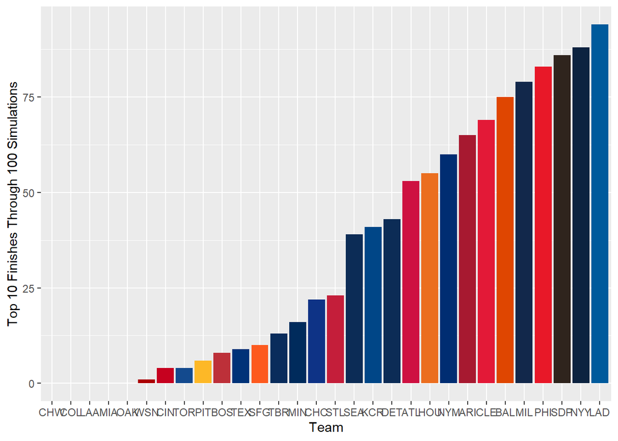

```r
top10 = ggplot(data = team_summary, aes(x = reorder(Home_Tm, Times_Top_10), y = Times_Top_10, fill = Home_Tm)) + geom_col() + scale_fill_manual(values = mlb_colors_custom) + theme(legend.position = "none") + labs(x = "Team", y = "Top 10 Finishes Through 100 Simulations" )
top10
```

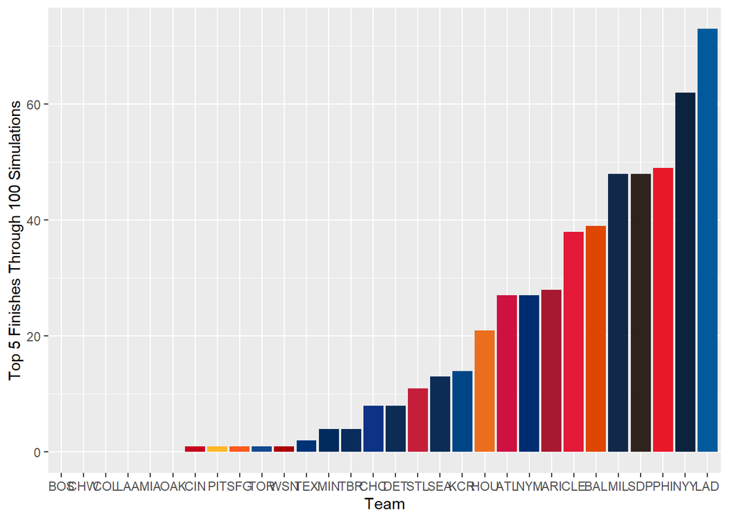

```r
top5 = ggplot(data = team_summary, aes(x = reorder(Home_Tm, Times_Top_5), y = Times_Top_5, fill = Home_Tm)) + geom_col()  + scale_fill_manual(values = mlb_colors_custom) + theme(legend.position = "none") + labs(x = "Team", y = "Top 5 Finishes Through 100 Simulations" )
top5
```

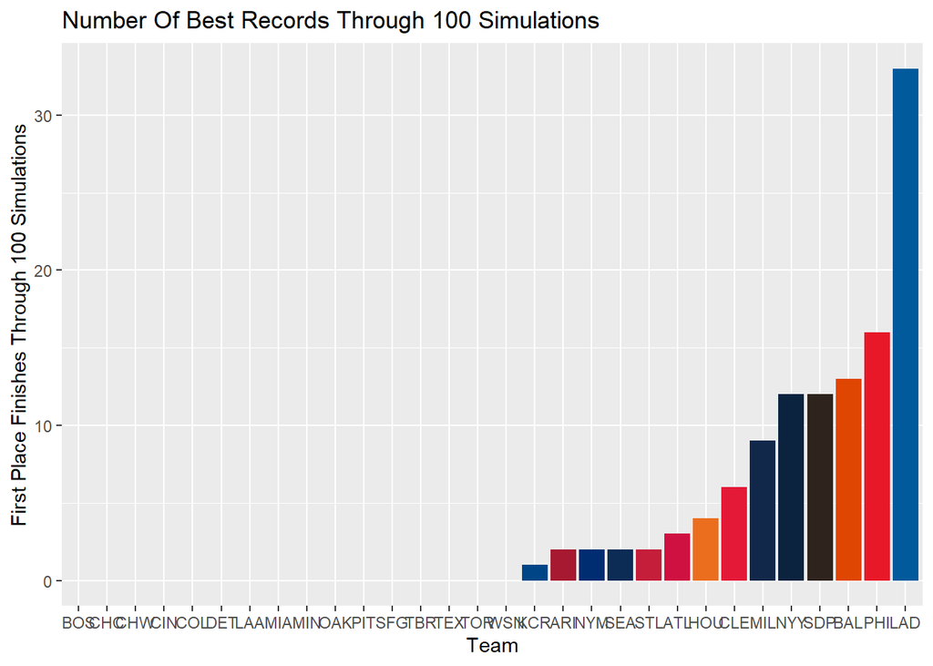

```r
top1 = ggplot(data = team_summary, aes(x = reorder(Home_Tm, Times_1st), y = Times_1st, fill = Home_Tm)) + geom_col() + scale_fill_manual(values = mlb_colors_custom) + theme(legend.position = "none") + labs(x = "Team", y = "Times First Place") + labs(x = "Team", y = "First Place Finishes Through 100 Simulations", title = "Number Of Best Records Through 100 Simulations")
top1
```

Sampling distribution of the average wins for each team across 100 simulations. Notice how close the simulated values track to the observed wins results. Although model performance scores suggest that the model is performing sufficiently, the fact that we are simulating the same season based on which we’ve trained the model on by intuitively means we will run into the issue of over fitting.

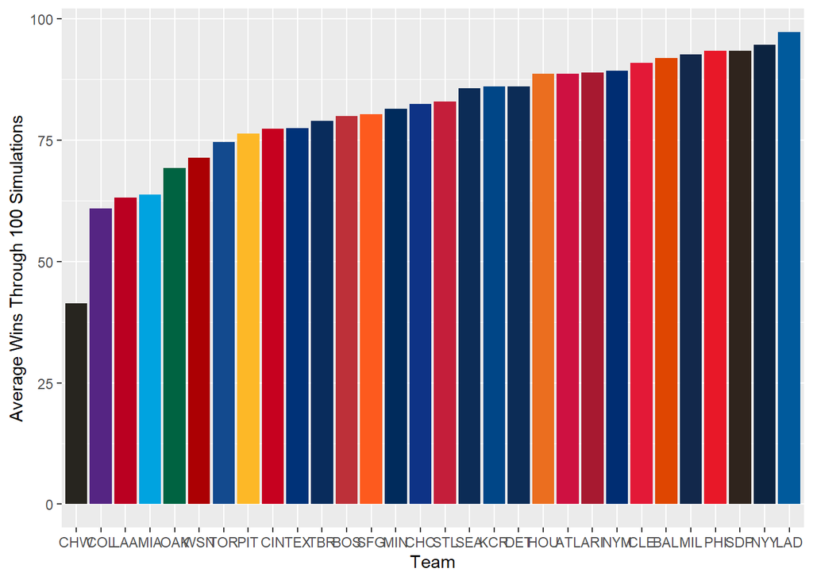

```r
records = ggplot(data = team_summary, aes(x = reorder(Home_Tm, Average_Wins), y = Average_Wins, fill = Home_Tm)) + geom_col() + scale_fill_manual(values = mlb_colors_custom) + theme(legend.position = "none") + labs(x = "Team", y = "Average Wins Through 100 Simulations" )
records
```

The gray fill represents the sampling distribution of the average wins across the 100 seasons, while the team color bar represents the actual win totals for the 2024 season.

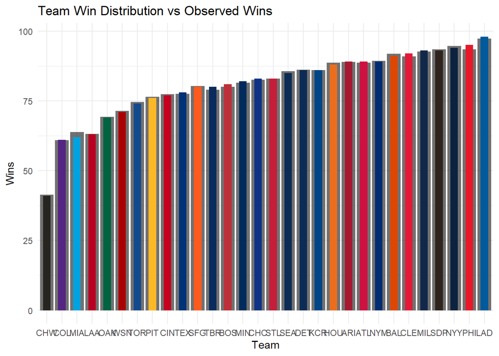

```r
ggplot(team_summary, aes(x = reorder(Home_Tm, Wins))) +
  geom_col(aes(y = Average_Wins), fill = "gray7", alpha = 0.6) +
  geom_col(aes(y = Wins, fill = Home_Tm), width = 0.5) +
  scale_fill_manual(values = mlb_colors_custom) +
  labs(x = "Team", y = "Wins", title = "Team Win Distribution vs Observed Wins") +
  theme_minimal() +
  theme(legend.position = "none")
```

#### Assessing Model Performance

We will now assess model accuracy by running metrics that output values representing weighted inaccuracy of predictions.

Brier Scoring and Log-Loss attempt to measure the inaccuracy of a prediction by measuring how far the predicted value $\hat{p}$ is from the observed value $Y$, in other words, “penalizing” very inaccurate predictions. Each metric does this in slightly different ways, yet the general idea remains the same.

Brier score computes the penalty via the following formula. This value is large when $\hat{p}$ is close to 1 and $Y$ is 0, and vise versa, therefore outputting a higher value when the prediction is far off from the observed value. Brier score is mathematically bounded between 0 and 1, where a score closer to represents a model that makes less wildly inaccurate predictions.

$$\text{Brier} = n^{-1}\sum_{i =
1}^{n}{(y_{i} - \hat{p}_{i})^2}.$$

```r
brier <- function(y, phat){
  return(mean( (y - phat)^2))
}
```

Log-Loss builds on the intuition behind the Brier score by penalizing aggressively wrong predictions even more. While Brier score is bounded betweem 0 and 1, Log-Loss can be infinitely large, since as $\hat{p}_{i} \rightarrow 0,$, $y_{i} \times \log{\hat{p}_{i}} \rightarrow -\infty.$.

$$\textrm{LogLoss} = -1 \times \sum_{i =
1}^{n}{\left[ y_{i} \times \log(\hat{p}_{i}) + (1 -
y_{i})\times\log(1-\hat{p}_{i})\right]}.$$

```r
logloss <- function(y, phat){

  if(any(phat < 1e-12)) phat[phat < 1e-12] <- 1e-12
  if(any(phat > 1-1e-12)) phat[phat > 1-1e-12] <- 1-1e-12
  return(-1 * mean( y * log(phat) + (1-y) * log(1-phat)))
}
```

To successfully compute the scores, minor adjustments are made to the data frame, such as representing the home and away team as numerical factors.

```r
games_with_pitchers_btm1 = games_with_pitchers_btm1 %>% mutate(Home_Tm = factor(Home_Tm, levels = unique_teams),
    Away_Tm = factor(Away_Tm,levels = unique_teams),
    Home_Athome = 1,
    Away_Athome = 0)
head(games_with_pitchers_btm1, n = 10)
```

```
## # A tibble: 10 × 36
##    Date       Home_Tm Away_Tm Home_Winner Away_Winner Winner Loser Home_Runs
##    <date>     <fct>   <fct>         <dbl>       <dbl> <chr>  <chr>     <dbl>
##  1 2024-03-20 SDP     LAD               0           1 LAD    SDP           2
##  2 2024-03-21 LAD     SDP               0           1 SDP    LAD          11
##  3 2024-03-28 BAL     LAA               1           0 BAL    LAA          11
##  4 2024-03-28 CHW     DET               0           1 DET    CHW           0
##  5 2024-03-28 KCR     MIN               0           1 MIN    KCR           1
##  6 2024-03-28 OAK     CLE               0           1 CLE    OAK           0
##  7 2024-03-28 SEA     BOS               0           1 BOS    SEA           4
##  8 2024-03-28 TBR     TOR               0           1 TOR    TBR           2
##  9 2024-03-28 TEX     CHC               1           0 TEX    CHC           4
## 10 2024-03-28 ARI     COL               1           0 ARI    COL          16
## # ℹ 28 more variables: Away_Runs <dbl>, Home_Pitcher <chr>,
## #   Home_Pitcher_ERA <dbl>, Home_Pitcher_IP <dbl>, Home_Pitcher_ER <dbl>,
## #   Home_Pitcher_ID <dbl>, Away_Pitcher <chr>, Away_Pitcher_ERA <dbl>,
## #   Away_Pitcher_IP <dbl>, Away_Pitcher_ER <dbl>, Away_Pitcher_ID <dbl>,
## #   Win_Pitch <chr>, Loss_Pitch <chr>, Save <chr>, cLI <dbl>, Gm <dbl>,
## #   Tm <chr>, DoubleHeader <dbl>, Date_String <date>, Date_Numeric <dbl>,
## #   game_id <dbl>, teamid <dbl>, Home_Ability <dbl>, Away_Ability <dbl>, …
```

A temporary data frame was then made for the purpose of estimating performance metrics.

```r
tmp_df = data.frame(game_id = games_with_pitchers_btm1$game_id, Home_Winner = games_with_pitchers_btm1$Home_Winner, Away_Winner = games_with_pitchers_btm1$Away_Winner, Home_Tm = games_with_pitchers_btm1$Home_Tm, Away_Tm = games_with_pitchers_btm1$Away_Tm)
```

A helper function to fit the theoretical home win probabiliteis was also created.

```r
lambda_hat = BTabilities(fit1)
Home_Win_Prob = function(home_team, away_team){
  diff_latent_strengths = lambda_hat[home_team, "ability"] - lambda_hat[away_team, "ability"]
  return(1 / (1 + exp(-1 * (diff_latent_strengths))))
}
```

To compute the Log Loss and Brier Score, we divide the data into random testing and training splits, and for each simulation we fit the Bradley Terry model and compute log loss and brier score. We then take the average brier score and logloss over every simulation.

```r
n_sims1 = 100
n1 = nrow(tmp_df)
n_train1 = floor(0.75 * n1)
n_test1 = n1 - n_train1

test_brier = rep(NA, times = n_sims1)
test_logloss = rep(NA, times = n_sims1)

for(r in 1:n_sims1){
  set.seed(479 + r)
  train_data =
    tmp_df %>%
    slice_sample(n = n_train1)
  test_data =
    tmp_df %>%
    dplyr::anti_join(y = train_data, by = "game_id")

  fit1 = BradleyTerry2::BTm(
  outcome = cbind(Home_Winner, Away_Winner),
  player1 = Home_Tm, player2 = Away_Tm,
  refcat = "ARI",
  id = "team",
  data = train_data)

  lambda_hat = BTabilities(fit1)
  test_preds1 = test_data %>% mutate(home_win_prob = Home_Win_Prob(Home_Tm, Away_Tm))

  test_logloss[r] = logloss(test_preds1$Home_Winner, test_preds1$home_win_prob)
  test_brier[r] = brier(test_preds1$Home_Winner, test_preds1$home_win_prob)
}
```

```r
cat("Model 1 Testing Logloss:", round(mean(test_logloss), digits = 3), "\n")
```

```
## Model 1 Testing Logloss: 0.684
```

```r
cat("Model 1 Testing Brier:", round(mean(test_brier), digits = 3), "\n")
```

```
## Model 1 Testing Brier: 0.245
```

These scores will eventually be compared to model performance scores from the other two models. In general, the lower the values for each of logloss and brier score, the “better” each model performs on the testing data. However, these values may be of less importance than normal given that these simulations just re-run the training data.

### Model 2: Adjusting Based on the Starting Pitcher and Home Team Advantage

We will now adjust the initial model based on starting pitcher performance as well as home field advantage. For this model, pitcher performance will be quantified as a function of both the home and away teams pitchers, more specifically, through a difference in their ERA’s, or earned run averages.

Although there is a multitude of statistics to choose from when quantifying pitcher performance, ERA was chosen due to its recognizability and simplicity. ERA is defined as the following, where “Earned” Runs are runs that are scored without a defensive error, therefore being the responsibility of the pitcher.

$$ERA = \frac{Earned \space Runs}{Innings
\space Pitched} * 9$$

Naming conventions with the 2 are used to avoid the possibility of overlapping variables, data frames, and functions, as each model was built on a separate local machine.

Data frame is loaded and arranged by date.

```r
season_2024 = read.csv("games_with_pitchers.csv")

season_2024 = season_2024 %>%
  arrange(Date, row_number())
```

To properly fit the Bradley Terry model, similar prepossessing steps were taken as in the first model, such as representing each teams home and away status in a factorized form, as well as mutation of the ERA strength statistic, which is simply the difference between home and away ERA’s.

```r
Bradley_Terry = season_2024 %>%
  transmute(
    home.team = factor(Home_Tm),
    away.team = factor(Away_Tm),
    home.win = as.integer(Home_Winner),
    away.win = as.integer(Away_Winner),
    at.home_home = 1,
    at.home_away = 0,
    era_difference_raw = Home_Pitcher_ERA - Away_Pitcher_ERA
  )%>%
  filter(!is.na(era_difference_raw)) %>%
  mutate(era_difference = era_difference_raw - mean(era_difference_raw, na.rm=TRUE))
```

```r
data_frame = data.frame(
  home.win = Bradley_Terry$home.win,
  away.win = Bradley_Terry$away.win
)

data_frame$home.team = data.frame(
  team = Bradley_Terry$home.team,
  at.home = 1,
  era = + Bradley_Terry$era_difference/2
)

data_frame$away.team = data.frame(
  team = Bradley_Terry$away.team,
  at.home = 0,
  era = - Bradley_Terry$era_difference/2
)
```

With prepossessing steps complete, the Bradley Terry Model can be fit using a similar syntax as before, this time including the new predictors of interest.

```r
set.seed(50)

fit2 = BTm(
  outcome = cbind(home.win, away.win),
  player1 = home.team,
  player2 = away.team,
  formula = ~ team + at.home + era,
  refcat = "ARI",
  id = "team",
  data = data_frame
)
summary(fit2)
```

```
##
## Call:
## BTm(outcome = cbind(home.win, away.win), player1 = home.team,
##     player2 = away.team, formula = ~team + at.home + era, id = "team",
##     refcat = "ARI", data = data_frame)
##
## Coefficients:
##          Estimate Std. Error z value Pr(>|z|)
## teamATL  0.071093   0.267381   0.266    0.790
## teamBAL  0.005221   0.274069   0.019    0.985
## teamBOS -0.338049   0.273341  -1.237    0.216
## teamCHC -0.114226   0.267416  -0.427    0.669
## teamCHW -1.177341   0.286216  -4.113 3.90e-05 ***
## teamCIN -0.224805   0.268250  -0.838    0.402
## teamCLE  0.286966   0.274773   1.044    0.296
## teamCOL -0.229452   0.266198  -0.862    0.389
## teamDET -0.070836   0.271141  -0.261    0.794
## teamHOU  0.023742   0.272564   0.087    0.931
## teamKCR -0.100282   0.272963  -0.367    0.713
## teamLAA -0.327628   0.277773  -1.179    0.238
## teamLAD  0.433176   0.269166   1.609    0.108
## teamMIA -0.382256   0.268993  -1.421    0.155
## teamMIL  0.165441   0.266654   0.620    0.535
## teamMIN -0.033753   0.275824  -0.122    0.903
## teamNYM  0.077619   0.268519   0.289    0.773
## teamNYY  0.182093   0.274919   0.662    0.508
## teamOAK -0.191317   0.273774  -0.699    0.485
## teamPHI  0.155562   0.270348   0.575    0.565
## teamPIT -0.204527   0.264914  -0.772    0.440
## teamSDP  0.253154   0.264421   0.957    0.338
## teamSEA -0.040967   0.270871  -0.151    0.880
## teamSFG  0.040737   0.263937   0.154    0.877
## teamSTL  0.078806   0.265003   0.297    0.766
## teamTBR -0.072546   0.267984  -0.271    0.787
## teamTEX -0.175303   0.272651  -0.643    0.520
## teamTOR -0.421019   0.276523  -1.523    0.128
## teamWSN -0.269475   0.268109  -1.005    0.315
## at.home  0.198609   0.049809   3.987 6.68e-05 ***
## era     -0.251458   0.012317 -20.416  < 2e-16 ***
## ---
## Signif. codes:  0 '***' 0.001 '**' 0.01 '*' 0.05 '.' 0.1 ' ' 1
##
## (Dispersion parameter for binomial family taken to be 1)
##
##     Null deviance: 3367.3  on 2429  degrees of freedom
## Residual deviance: 2465.0  on 2398  degrees of freedom
## AIC: 2527
##
## Number of Fisher Scoring iterations: 7
```

```r
team_abilities = BradleyTerry2::BTabilities(fit2) %>%
  as.data.frame()%>%
  rownames_to_column("Team") %>%
  arrange(desc(ability))
team_abilities
```

```
##    Team      ability      s.e.
## 1   LAD  0.433175750 0.2691660
## 2   CLE  0.286965828 0.2747729
## 3   SDP  0.253153651 0.2644210
## 4   NYY  0.182093158 0.2749186
## 5   MIL  0.165441159 0.2666545
## 6   PHI  0.155562107 0.2703482
## 7   STL  0.078806065 0.2650027
## 8   NYM  0.077618915 0.2685186
## 9   ATL  0.071093294 0.2673810
## 10  SFG  0.040737412 0.2639366
## 11  HOU  0.023741791 0.2725641
## 12  BAL  0.005220983 0.2740693
## 13  ARI  0.000000000 0.0000000
## 14  MIN -0.033753160 0.2758236
```

[output cut: 16 more lines]

```r
coefficient = coef(fit2)

home_adventage = unname(coefficient["at.home"])
```

Something of note we can also do is estimate a confidence interval for each team’s ability since we have a standard error. To create a nice visualization of these intervals, we rank each team by their estimated Bradley-Terry ability

```r
rank = team_abilities %>%
  mutate(
    Rank = rank(-ability, ties.method = "min"),
    low = ability - 1.96 * `s.e.`,
    high = ability + 1.96 * `s.e.`,
  ) %>%
  select(Rank, Team, ability, low, high,`s.e.`)
```

```r
rank
```

```
##    Rank Team      ability         low       high      s.e.
## 1     1  LAD  0.433175750 -0.09438965  0.9607411 0.2691660
## 2     2  CLE  0.286965828 -0.25158903  0.8255207 0.2747729
## 3     3  SDP  0.253153651 -0.26511150  0.7714188 0.2644210
## 4     4  NYY  0.182093158 -0.35674735  0.7209337 0.2749186
## 5     5  MIL  0.165441159 -0.35720158  0.6880839 0.2666545
## 6     6  PHI  0.155562107 -0.37432046  0.6854447 0.2703482
## 7     7  STL  0.078806065 -0.44059922  0.5982114 0.2650027
## 8     8  NYM  0.077618915 -0.44867758  0.6039154 0.2685186
## 9     9  ATL  0.071093294 -0.45297341  0.5951600 0.2673810
## 10   10  SFG  0.040737412 -0.47657836  0.5580532 0.2639366
## 11   11  HOU  0.023741791 -0.51048393  0.5579675 0.2725641
## 12   12  BAL  0.005220983 -0.53195491  0.5423969 0.2740693
## 13   13  ARI  0.000000000  0.00000000  0.0000000 0.0000000
## 14   14  MIN -0.033753160 -0.57436738  0.5068611 0.2758236
```

[output cut: 16 more lines]

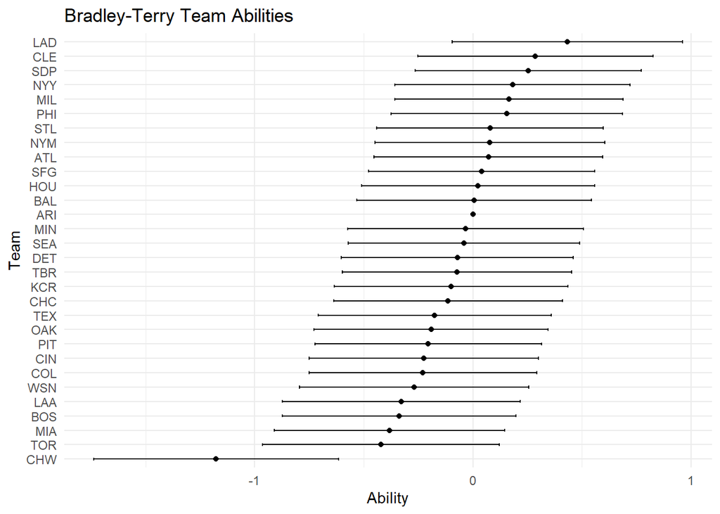

```r
ggplot(rank, aes(x = reorder(Team, ability), y = ability))+
  geom_point()+
  geom_errorbar(aes(ymin = low, ymax = high), width = 0.2)+
  coord_flip()+
  labs(
    title = "Bradley-Terry Team Abilities",
    x = "Team",
    y = "Ability"
  )+theme_minimal()
```

We are now ready to simulate 100 seasons using this model as before. Using similar techniques of spliiting the results into home and away teams and then re-joining them, we are able to append the theoretical probabilities and estimated abilities of each team to the main data set.

```r
home_ability = team_abilities %>%
  select(Team, ability) %>%
  rename(home.team = Team, ability_home = ability)

away_ability = team_abilities %>%
  select(Team, ability) %>%
  rename(away.team = Team, ability_away = ability)

evaluation = Bradley_Terry  %>%
  mutate(row_id = row_number()) %>%
  left_join(home_ability, by = "home.team") %>%
  left_join(away_ability, by = "away.team") %>%
  mutate(
    linear_predictor = (ability_home - ability_away) + home_adventage * 1,
    probability_home_team = 1/ (1 + exp(-linear_predictor)),
    y = home.win
  )
```

```r
head(evaluation, n = 10)
```

```
##    home.team away.team home.win away.win at.home_home at.home_away
## 1        SDP       LAD        0        1            1            0
## 2        LAD       SDP        0        1            1            0
## 3        BAL       LAA        1        0            1            0
## 4        CHW       DET        0        1            1            0
## 5        KCR       MIN        0        1            1            0
## 6        OAK       CLE        0        1            1            0
## 7        SEA       BOS        0        1            1            0
## 8        TBR       TOR        0        1            1            0
## 9        TEX       CHC        1        0            1            0
## 10       ARI       COL        1        0            1            0
##    era_difference_raw era_difference row_id ability_home ability_away
## 1           -3.600000      -3.017211      1  0.253153651   0.43317575
## 2           28.124996      28.707785      2  0.433175750   0.25315365
## 3          -14.700006     -14.117218      3  0.005220983  -0.32762830
```

[output cut: 18 more lines]

As before, we simulate the season 100 times with the assistance of uniform random variables and bind the results of each data frame.

```r
n_sims = 100

simulation_results2 = replicate(n_sims, (evaluation
                               %>% mutate(
                      random_number = runif(n()),
                      Home_Simulated_Win = ifelse(probability_home_team > random_number, 1, 0),
                      Away_Simulated_Win = 1 - Home_Simulated_Win)
                               ), simplify = FALSE)
```

```r
simulation_df2 = bind_rows(simulation_results2, .id = "sim_id")
```

```r
head(simulation_df2, n = 10)
```

```
##    sim_id home.team away.team home.win away.win at.home_home at.home_away
## 1       1       SDP       LAD        0        1            1            0
## 2       1       LAD       SDP        0        1            1            0
## 3       1       BAL       LAA        1        0            1            0
## 4       1       CHW       DET        0        1            1            0
## 5       1       KCR       MIN        0        1            1            0
## 6       1       OAK       CLE        0        1            1            0
## 7       1       SEA       BOS        0        1            1            0
## 8       1       TBR       TOR        0        1            1            0
## 9       1       TEX       CHC        1        0            1            0
## 10      1       ARI       COL        1        0            1            0
##    era_difference_raw era_difference row_id ability_home ability_away
## 1           -3.600000      -3.017211      1  0.253153651   0.43317575
## 2           28.124996      28.707785      2  0.433175750   0.25315365
## 3          -14.700006     -14.117218      3  0.005220983  -0.32762830
```

[output cut: 29 more lines]

```r
# Summarize wins by team across all simulations
hundred_season_summary2  = simulation_df2 %>%
  group_by(sim_id, home.team) %>%
  summarize(Home_Wins = sum(Home_Simulated_Win), .groups = 'drop') %>%
  left_join(
    simulation_df2 %>%
      group_by(sim_id, away.team) %>%
      summarize(Away_Wins = sum(Away_Simulated_Win), .groups = 'drop'),
    by = c("sim_id", "home.team" = "away.team")
  ) %>%
  mutate(
    Total_Wins = Home_Wins + Away_Wins,
    Home_Losses = 81 - Home_Wins,
    Away_Losses = 81 - Away_Wins,
    Total_Losses = 162 - Total_Wins
  )

head(hundred_season_summary2, n = 10)
```

```
## # A tibble: 10 × 8
##    sim_id home.team Home_Wins Away_Wins Total_Wins Home_Losses Away_Losses
##    <chr>  <chr>         <dbl>     <dbl>      <dbl>       <dbl>       <dbl>
##  1 1      ARI              50        40         90          31          41
##  2 1      ATL              52        36         88          29          45
##  3 1      BAL              45        41         86          36          40
##  4 1      BOS              34        33         67          47          48
##  5 1      CHC              45        31         76          36          50
##  6 1      CHW              31        19         50          50          62
##  7 1      CIN              35        32         67          46          49
##  8 1      CLE              58        48        106          23          33
##  9 1      COL              43        30         73          38          51
## 10 1      DET              50        39         89          31          42
## # ℹ 1 more variable: Total_Losses <dbl>
```

```r
# Eval set to FALSE due to some errors upon knitting
n_sims = 100

team_rankings2 = hundred_season_summary2 %>%
  group_by(sim_id) %>%
  mutate(League_Rank = rank(-Total_Wins, ties.method = "min")) %>%
  ungroup()

team_summary2 = team_rankings2 %>%
  group_by(home.team) %>%
  summarize(
    Average_Rank = mean(League_Rank),
    q25_rank = quantile(League_Rank, 0.25, na.rm = TRUE),
    q75_rank = quantile(League_Rank, 0.75, na.rm = TRUE),
    Times_1st = sum(League_Rank == 1),
    Times_Top_5 = sum(League_Rank <= 5),
    Times_Top_10 = sum(League_Rank <= 10),
    Average_Wins = mean(Total_Wins),
    q25_wins = quantile(Total_Wins, 0.25),
    q75_wins = quantile(Total_Wins, 0.75),
    Average_Losses = mean(Total_Losses),
    Max_Wins = max(Total_Wins),
    Min_Wins = min(Total_Wins),
    Prob_1st = Times_1st / n_sims,
    Prob_Top_5 = Times_Top_5 / n_sims,
    Prob_Top_10 = Times_Top_10 / n_sims,
    .groups = 'drop'
  )

team_summary2
```

```r
save(team_summary2, file = "team_summary2.Rda")
```

```r
load("team_summary2.Rda")
```

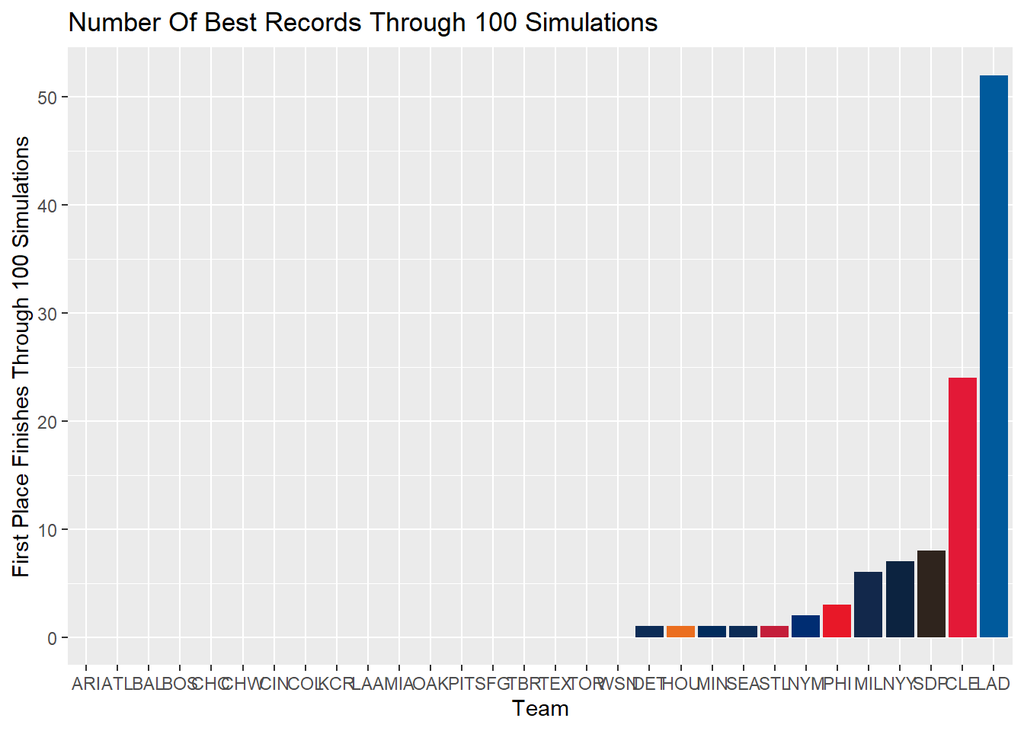

```r
top1.2 = ggplot(data = team_summary2, aes(x = reorder(home.team, Times_1st), y = Times_1st, fill = home.team)) + geom_col() + scale_fill_manual(values = mlb_colors_custom) + theme(legend.position = "none") + labs(x = "Team", y = "Times First Place") + labs(x = "Team", y = "First Place Finishes Through 100 Simulations", title = "Number Of Best Records Through 100 Simulations")
top1.2
```

[figure not shown]

```r
ggplot(data = team_summary2, aes(x = reorder(home.team, Average_Wins), y = Average_Wins, fill = home.team)) + geom_col() + scale_fill_manual(values = mlb_colors_custom) + theme(legend.position = "none") + labs(x = "Team", y = "Times First Place") + labs(x = "Team", y = "First Place Finishes Through 100 Simulations", title = "Number Of Best Records Through 100 Simulations")
```

#### Assessing Model Performance

We now assess model performance using the same metrics as before with similar methodology.

Model performance is calcuated using virtually the same methodology as for the baseline model.

```r
set.seed(50)

n = nrow(games_with_pitchers)

cv_log = data.frame()

for(r in 1:100){
  train_idx = sample(1:n, size = floor(0.75*n), replace = FALSE)
  train_df = games_with_pitchers[train_idx,]
  test_df = games_with_pitchers[-train_idx,]
  unik_teams = sort(unique(c(train_df$Home_Tm, train_df$Away_Tm)))

  results_train = train_df %>%
    rename(home_team = Home_Tm, away_team = Away_Tm) %>%
  mutate(
    home_team = factor(home_team, levels = unik_teams),
    away_team = factor(away_team,levels = unik_teams),
    home_athome = 1,
    away_athome = 0)

  results_test = test_df %>%
    rename(home_team = Home_Tm, away_team = Away_Tm)%>%
    mutate(
      home_team = factor(home_team, levels = unik_teams),
      away_team = factor(away_team, levels = unik_teams),
      home_athome =1,
      away_athome = 0
    )
  tmp_df <- data.frame(Home_Winner = results_train$Home_Winner, Away_Winner = results_train$Away_Winner)

  tmp_df$home_team <- data.frame(team = results_train$home_team, at_home = results_train$home_athome, pitcher_era = results_train$Home_Pitcher_ERA)

  tmp_df$away_team <- data.frame(team = results_train$away_team, at_home = results_train$away_athome, pitcher_era = results_train$Away_Pitcher_ERA)

  fit_sim <-
  BTm(
    outcome = cbind(Home_Winner, Away_Winner),
    player1 = home_team, player2 = away_team,
    formula = ~ team + at_home + pitcher_era,
    refcat = "ARI",
    id = "team",
    data = tmp_df)

  abil_mat = BTabilities(fit_sim)
  abil = abil_mat[,"ability"]
  beta_home = coef(fit_sim)["at_home"]
  beta_era = coef(fit_sim)["pitcher_era"]

  home = as.character(results_test$home_team)
  away = as.character(results_test$away_team)
  difference_in_abil = abil[home] - abil[away]
  difference_era = results_test$Home_Pitcher_ERA - results_test$Away_Pitcher_ERA

  phat = plogis(difference_in_abil + beta_home + difference_era * beta_era)

  cv_log = rbind(cv_log,
                 data.frame(iter = r,
                            brier=brier(results_test$Home_Winner, phat),
                            logloss=logloss(results_test$Home_Winner, phat)))
}
summary(fit_sim)
```

```
##
## Call:
## BTm(outcome = cbind(Home_Winner, Away_Winner), player1 = home_team,
##     player2 = away_team, formula = ~team + at_home + pitcher_era,
##     id = "team", refcat = "ARI", data = tmp_df)
##
## Coefficients:
##              Estimate Std. Error z value Pr(>|z|)
## teamATL      0.132934   0.299534   0.444 0.657185
## teamBAL      0.010434   0.303832   0.034 0.972605
## teamBOS     -0.227526   0.312837  -0.727 0.467042
## teamCHC      0.017493   0.294362   0.059 0.952613
## teamCHW     -1.073019   0.322706  -3.325 0.000884 ***
## teamCIN     -0.200745   0.293640  -0.684 0.494201
## teamCLE      0.342977   0.303059   1.132 0.257753
## teamCOL     -0.159876   0.300241  -0.532 0.594384
## teamDET     -0.005281   0.305186  -0.017 0.986195
## teamHOU      0.243851   0.308307   0.791 0.428982
## teamKCR      0.100519   0.311899   0.322 0.747241
## teamLAA     -0.158827   0.316624  -0.502 0.615931
## teamLAD      0.557457   0.305026   1.828 0.067614 .
## teamMIA     -0.398340   0.311256  -1.280 0.200622
## teamMIL      0.188600   0.303992   0.620 0.534986
## teamMIN      0.039890   0.310032   0.129 0.897624
## teamNYM      0.209591   0.307175   0.682 0.495039
## teamNYY      0.156105   0.306832   0.509 0.610917
## teamOAK      0.016922   0.307509   0.055 0.956115
## teamPHI      0.208152   0.304838   0.683 0.494715
## teamPIT     -0.140050   0.292987  -0.478 0.632645
## teamSDP      0.370530   0.296915   1.248 0.212055
## teamSEA      0.110422   0.309248   0.357 0.721041
## teamSFG      0.065980   0.295333   0.223 0.823217
## teamSTL      0.119889   0.294059   0.408 0.683490
## teamTBR      0.024249   0.298888   0.081 0.935338
## teamTEX     -0.166015   0.306117  -0.542 0.587595
## teamTOR     -0.473861   0.312096  -1.518 0.128934
## teamWSN     -0.112095   0.302051  -0.371 0.710554
## at_home      0.076204   0.056248   1.355 0.175484
## pitcher_era -0.235426   0.013718 -17.162  < 2e-16 ***
## ---
## Signif. codes:  0 '***' 0.001 '**' 0.01 '*' 0.05 '.' 0.1 ' ' 1
##
## (Dispersion parameter for binomial family taken to be 1)
##
##     Null deviance: 2524.4  on 1821  degrees of freedom
## Residual deviance: 1879.8  on 1790  degrees of freedom
## AIC: 1941.8
##
## Number of Fisher Scoring iterations: 21
```

Finally, after fitting the Bradley-Terry model with team ability, home field advantage, and starting pitcher effects, we examined the estimated coefficients. Each team has a coefficient relative to Arizona Diamondbacks, with most not being statistically significant individually since the model estimates relative strength conditional on opponents and pitcher effects. The home field effect is estimated at 0.076, slightly increasing log-odds of winning, but with a p-value of 0.17 it’s not statistically significant.

However, the pitcher ERA effect of -0.235 is highly significant (p < 2e-16), meaning a better starting pitcher ERA strongly increases home team win probability. Cross-validation across 100 randomized 75/25 splits yielded an average Brier score of 0.161 and log loss of 0.521—both substantially lower than the simpler model’s 0.245 and 0.684. Since lower scores generally indicate better performance, adding starting pitcher and home field advantage clearly improves predictions, with pitcher ERA being the key driver of enhanced accuracy.

```r
cv_log %>%
  summarize(mean_brier = mean(brier),
            mean_logloss = mean(logloss))
```

```
##   mean_brier mean_logloss
## 1  0.1609381    0.5211772
```

### Model 3: Adjusting Based on Recent Team Performance

**BT Model #3: Accounting for Team Form:**

The third and final Bradley-Terry Model we built accounts for one additional variable: team form.

**Motivation:**

Over the course of a 162 game season, it is common for players and teams to go on hot and cold stretches, periods where teams win or lose many more games than expected. Because of this, we question if accounting for recent team performance will make our model more accurate.

**Team Form:**

We define team form as a team’s win rate over their last 15 games.

**1. Building our BT Model #3:**

First, we load in the dataframe and execute similar pre-processing steps as in prior models.

```r
unik_teams3 <- sort(unique(c(games_with_pitchers$Home_Tm, games_with_pitchers$Away_Tm)))

results3 <- games_with_pitchers %>%
  rename(home_team = Home_Tm, away_team = Away_Tm) %>%
  mutate(
    home_team = factor(home_team, levels = unik_teams3),
    away_team = factor(away_team,levels = unik_teams3),
    home_athome = 1,
    away_athome = 0) %>%
  select(Date, game_id, home_team, away_team, Home_Winner, Away_Winner, home_athome, away_athome, Home_Pitcher_ERA, Away_Pitcher_ERA)
```

**Create Home Win Probability Function:**

We then define our home win probability function. This will be used to compute theoretical win probabilities for the home team in every regular season game.

It takes six arguments:

1. home_team
2. away_team
3. home_pitcher_ERA
4. away_pitcher_ERA
5. home_team_form
6. away_team_form

It then uses these variables to compute the difference in latent strengths, difference in pitcher ERAs, and difference in team forms, which are plugged into the formula for the probability that team H (the home team) beats team A (the away team) at H’s home.

```r
Home_Win_Prob3 <- function(home_team, away_team, home_pitcher_era,
                          away_pitcher_era, home_team_form, away_team_form) {
  diff_latent_strengths <-
    lambda_hat[home_team, "ability"] - lambda_hat[away_team, "ability"]

  diff_pitcher_eras <- (home_pitcher_era - away_pitcher_era)

  diff_team_forms <- (home_team_form - away_team_form)

  return(1/(1 + exp(-1 * (diff_latent_strengths + lambda_home + (diff_pitcher_eras*lambda_pitcher_era) + (diff_team_forms * lambda_form)))))
}
```

**Creating Team Form Variable**:

To build our BT model which accounts for team form, we first must derive two new variables: home_team_form and away_team_form.

We derive these team form variables by pivoting our dataframe into a longer format where each row corresponds to a unique team and game. And each row contains information as to whether each team won or lost the game.

We then use this longer dataframe to compute each team’s win rate (over their last 15 games). And combine this dataframe (containing team form) with our original dataframe.

```r
# Ensure Date is a proper Date type and games are in order
results3 <- results3 %>%
  mutate(Date = as.Date(Date)) %>%
  arrange(Date)

# Long format: one row per team per game
results_long <- results3 %>%
  mutate(Game_ID = row_number()) %>%
  pivot_longer(
    cols = c(home_team, away_team),
    names_to = "Side",
    values_to = "Team"
  ) %>%
  mutate(
    Win = ifelse(Side == "home_team", Home_Winner, Away_Winner)
  ) %>%
  select(Game_ID, Date, Team, Win)

# Compute each team's rolling win rate (last 15 games)
results_form <- results_long %>%
  group_by(Team) %>%
  arrange(Date) %>%
  mutate(
    team_form = map_dbl(seq_along(Win), function(i) {
      past_games <- Win[max(1, i - 15):(i - 1)]
      if (length(past_games) == 0) return(NA_real_)
      mean(past_games)
    })
  ) %>%
  ungroup()

# Join both home and away team form values back to main dataset
results_form <- results_form %>%
  group_by(Game_ID, Date) %>%
  arrange(Game_ID, Date, row_number()) %>%  # ensure order within game
  mutate(team_order = row_number()) %>%
  summarise(
    home_team = Team[team_order == 1],
    away_team = Team[team_order == 2],
    home_winner = Win[team_order == 1],
    away_winner = Win[team_order == 2],
    home_team_form = team_form[team_order == 1],
    away_team_form = team_form[team_order == 2],
    .groups = "drop"
  ) %>%
  rename(game_id = "Game_ID", Home_Winner = "home_winner", Away_Winner = "away_winner")

results3 <- inner_join(results3, results_form)
```

[output not shown]

**Create Temporary Data frame to Fit our Model:**

To fit the Bradley-Terry Model, our data needs to be in a particular format. The response variables Home_Winner and Away_Winner (indicator variables which indicate whether the home and away teams won or lost) must be stored in a temporary dataframe first.

Then data frames for the home and away teams (containing all of the relevant variables) are appended to the original temporary dataframe.

```r
# more knitting issues
tmp_df3 <- data.frame(game_id = results3$game_id, Home_Winner = results3$Home_Winner, Away_Winner = results3$Away_Winner)

##Home Data frame appended to temp Data frame
tmp_df3$home_team <- data.frame(team = results3$home_team, at_home = results3$home_athome, pitcher_era = results3$Home_Pitcher_ERA, form = results3$home_team_form)

##Away Data frame appended to temp Data frame
tmp_df3$away_team <- data.frame(team = results3$away_team, at_home = results3$away_athome, pitcher_era = results3$Away_Pitcher_ERA, form = results3$away_team_form)
```

```r
save(tmp_df3, file = "tmp_df3.Rda")
```

```r
load("tmp_df3.Rda")
```

The model is now fit using similar syntax as before, this time including the team form metric.

```r
fit_form3 <-
    BTm(
      outcome = cbind(Home_Winner, Away_Winner),
      player1 = home_team, player2 = away_team,
      formula = ~ team + at_home + pitcher_era + form,
      refcat = "ARI",
      id = "team",
      data = tmp_df3)
summary(fit_form3)
```

```
##
## Call:
## BTm(outcome = cbind(Home_Winner, Away_Winner), player1 = home_team,
##     player2 = away_team, formula = ~team + at_home + pitcher_era +
##         form, id = "team", refcat = "ARI", data = tmp_df3)
##
## Coefficients:
##              Estimate Std. Error z value Pr(>|z|)
## teamATL      0.070213   0.267360   0.263 0.792845
## teamBAL      0.004206   0.274057   0.015 0.987754
## teamBOS     -0.333437   0.273664  -1.218 0.223067
## teamCHC     -0.111181   0.267551  -0.416 0.677737
## teamCHW     -1.149442   0.297657  -3.862 0.000113 ***
## teamCIN     -0.219850   0.268688  -0.818 0.413222
## teamCLE      0.285964   0.274824   1.041 0.298091
## teamCOL     -0.213527   0.270273  -0.790 0.429504
## teamDET     -0.071284   0.271138  -0.263 0.792622
## teamHOU      0.029598   0.273124   0.108 0.913703
## teamKCR     -0.097625   0.273070  -0.358 0.720710
## teamLAA     -0.313336   0.280907  -1.115 0.264660
## teamLAD      0.427068   0.269738   1.583 0.113360
## teamMIA     -0.363355   0.274572  -1.323 0.185718
## teamMIL      0.160361   0.267064   0.600 0.548201
## teamMIN     -0.032049   0.275929  -0.116 0.907535
## teamNYM      0.084451   0.269295   0.314 0.753825
## teamNYY      0.178304   0.275106   0.648 0.516902
## teamOAK     -0.177831   0.276640  -0.643 0.520339
## teamPHI      0.156103   0.270400   0.577 0.563735
## teamPIT     -0.199023   0.265395  -0.750 0.453307
## teamSDP      0.251936   0.264426   0.953 0.340709
## teamSEA     -0.034656   0.271519  -0.128 0.898435
## teamSFG      0.045427   0.264314   0.172 0.863541
## teamSTL      0.082983   0.265278   0.313 0.754421
## teamTBR     -0.066595   0.268518  -0.248 0.804128
## teamTEX     -0.169292   0.273229  -0.620 0.535522
## teamTOR     -0.412095   0.277715  -1.484 0.137841
## teamWSN     -0.258372   0.270089  -0.957 0.338760
## at_home      0.052962   0.049326   1.074 0.282948
## pitcher_era -0.251516   0.012320 -20.415  < 2e-16 ***
## form         0.076948   0.225530   0.341 0.732963
## ---
## Signif. codes:  0 '***' 0.001 '**' 0.01 '*' 0.05 '.' 0.1 ' ' 1
##
## (Dispersion parameter for binomial family taken to be 1)
##
##     Null deviance: 3367.3  on 2429  degrees of freedom
## Residual deviance: 2464.8  on 2397  degrees of freedom
## AIC: 2528.8
##
## Number of Fisher Scoring iterations: 7
```

Above, you can see a summary output for our model. Surprisingly, the effect of team form was not statistically significant. We obtained an estimate of approximately 0.077.

**2. Assessing Model Accuracy:**

Individual coefficients and key values are extracted from the model for later use.

We extract the lambdas for the latent team strengths, for home advantage, for team form, and for pitcher Eras. These lambdas will be plugged into our home_win_prob function to obtain theoretical home win probabilities.

```r
lambda_hat <- BTabilities(fit_form3)
lambda_home <- coef(fit_form3)["at_home"]
lambda_form <- coef(fit_form3)["form"]
lambda_pitcher_era <- coef(fit_form3)["pitcher_era"]
```

#### Assessing Model Performance

```r
n_sims <- 100
n_row = nrow(tmp_df3)
n_train <- floor(0.75*n_row)

##Initialize testing log loss vector
test_logloss3 <- rep(NA, times = n_sims)
test_brier3 <- rep(NA, times = n_sims)

for(r in 1:n_sims){
  set.seed(479+r)
  train_data3 <-
    tmp_df3 |>
    dplyr::slice_sample(n = n_train)
  test_data3 <-
    results3 |>
    dplyr::anti_join(y = train_data3, by = "game_id")

  ##Fit model using training data
  fit_form3 <-
    BTm(
      outcome = cbind(Home_Winner, Away_Winner),
      player1 = home_team, player2 = away_team,
      formula = ~ team + at_home + pitcher_era + form,
      refcat = "ARI",
      id = "team",
      data = train_data3)

  ##Extract Lambdas
  lambda_hat3 <- BTabilities(fit_form3)
  lambda_home3 <- coef(fit_form3)["at_home"]
  lambda_form3 <- coef(fit_form3)["form"]
  lambda_pitcher_era3 <- coef(fit_form3)["pitcher_era"]


  ##Make predictions on testing data
  test_preds_df3 <- test_data3 %>%
    mutate(home_win_prob = Home_Win_Prob3(home_team, away_team, Home_Pitcher_ERA, Away_Pitcher_ERA, home_team_form, away_team_form))

  ##Compute log-loss and Brier score and store them in the log-loss and brier score vectors
  test_logloss3[r] <-
    logloss(test_preds_df3$Home_Winner, test_preds_df3$home_win_prob)
  test_brier3[r] <-
    brier(test_preds_df3$Home_Winner, test_preds_df3$home_win_prob)
}
cat("Dist testing logloss:", round(mean(test_logloss3), digits = 3), "\n")
```

```
## Dist testing logloss: 0.503
```

```r
cat("Dist testing brier:", round(mean(test_brier3), digits = 3), "\n")
```

```
## Dist testing brier: 0.155
```

This model obtains lower log loss and brier scores than both the baseline and non team form model, suggesting superior accuracy at predicting outcomes.

**3. Analysis with BT Model 3**

**Distribution of Wins:**

As with prior models, we must simulate the MLB season the desired amount of times as the model has now been fit.

```r
preds_df_3 <- results3 %>%
    mutate(home_win_prob = Home_Win_Prob3(home_team, away_team, Home_Pitcher_ERA, Away_Pitcher_ERA, home_team_form, away_team_form))
```

Distribution of Wins

```r
n_sims <- 100

simulations_results_3 <-
  replicate(n_sims, (preds_df_3 %>%
                         mutate(
                         random_number = runif(n()),
                         Home_Simulated_Win = ifelse(home_win_prob > random_number, 1, 0),
                         Away_Simulated_Win = 1 - Home_Simulated_Win)
  ), simplify = FALSE)
```

```r
simulation_df3 = bind_rows(simulations_results_3, .id = "sim_id")
head(simulation_df3, n = 10)
```

```
## # A tibble: 10 × 17
##    sim_id Date       game_id home_team away_team Home_Winner Away_Winner
##    <chr>  <date>       <dbl> <fct>     <fct>           <dbl>       <dbl>
##  1 1      2024-03-20       1 SDP       LAD                 0           1
##  2 1      2024-03-21       2 LAD       SDP                 0           1
##  3 1      2024-03-28       3 BAL       LAA                 1           0
##  4 1      2024-03-28       4 CHW       DET                 0           1
##  5 1      2024-03-28       5 KCR       MIN                 0           1
##  6 1      2024-03-28       6 OAK       CLE                 0           1
##  7 1      2024-03-28       7 SEA       BOS                 0           1
##  8 1      2024-03-28       8 TBR       TOR                 0           1
##  9 1      2024-03-28       9 TEX       CHC                 1           0
## 10 1      2024-03-28      10 ARI       COL                 1           0
## # ℹ 10 more variables: home_athome <dbl>, away_athome <dbl>,
## #   Home_Pitcher_ERA <dbl>, Away_Pitcher_ERA <dbl>, home_team_form <dbl>,
## #   away_team_form <dbl>, home_win_prob <dbl>, random_number <dbl>,
## #   Home_Simulated_Win <dbl>, Away_Simulated_Win <dbl>
```

```r
hundred_season_summary_tmp_1 <- simulation_df3 %>%
  group_by(sim_id, home_team) %>%
  summarize(Home_Wins = sum(Home_Simulated_Win)) %>%
  rename(team = home_team)
hundred_season_summary_tmp_2 <- simulation_df3 %>%
  group_by(sim_id, away_team) %>%
  summarize(Away_Wins = sum(Away_Simulated_Win)) %>%
  rename(team = away_team)
hundred_season_summary_3 <- hundred_season_summary_tmp_1 %>%
  left_join(hundred_season_summary_tmp_2, by = c("team", "sim_id")) %>%
  mutate(Total_Wins = Home_Wins + Away_Wins, Home_Losses = 81 - Home_Wins, Away_Losses = 81 - Away_Wins, Total_Losses = 162 - Total_Wins)
```

Summary Statistics for Distribution of Wins

```r
team_rankings3 = hundred_season_summary_3 %>%
  group_by(sim_id) %>%
  mutate(League_Rank = rank(-Total_Wins, ties.method = "min")) %>%
  ungroup()

##Table with Summary Statistics
team_summary3 = team_rankings3 %>%
  group_by(team) %>%
  summarize(Average_Rank = mean(League_Rank),
            q25_rank = quantile(League_Rank, 0.25),
            q75_rank = quantile(League_Rank, 0.75),
            Times_1st = sum(League_Rank == 1),
            Times_Top_5 = sum(League_Rank <= 5),
            Times_Top_10 = sum(League_Rank <= 10),
            Average_Wins = mean(Total_Wins),
            q25_wins = quantile(Total_Wins, 0.25),
            q75_wins = quantile(Total_Wins, 0.75),
            Average_Losses = mean(Total_Losses),
            Max_Wins = max(Total_Wins),
            Min_Wins = min(Total_Wins),
            Prob_1st = Times_1st/ n_sims,
            Prob_Top_5 = Times_Top_5 / n_sims,
            Prob_Top_10 = Times_Top_10 / n_sims
)
```

```r
head(team_summary3, n = 10)
```

```
## # A tibble: 10 × 16
##    team  Average_Rank q25_rank q75_rank Times_1st Times_Top_5 Times_Top_10
##    <fct>        <dbl>    <dbl>    <dbl>     <int>       <int>        <int>
##  1 ARI           9.04     5        13           4          28           60
##  2 ATL           9.39     5.75     13           2          25           63
##  3 BAL           7.78     3.75     11           6          39           71
##  4 BOS          16.7     14        20           0           2           10
##  5 CHC          14.7     11        18.2         0           6           23
##  6 CHW          30       30        30           0           0            0
##  7 CIN          20.4     18        23           0           0            0
##  8 CLE           7.21     3        10.2        12          45           75
##  9 COL          27.6     27        29           0           0            0
## 10 DET          11.9      8        15.2         0           8           39
## # ℹ 9 more variables: Average_Wins <dbl>, q25_wins <dbl>, q75_wins <dbl>,
## #   Average_Losses <dbl>, Max_Wins <dbl>, Min_Wins <dbl>, Prob_1st <dbl>,
## #   Prob_Top_5 <dbl>, Prob_Top_10 <dbl>
```

```r
home_winners = games_with_pitchers %>% group_by(Home_Tm) %>% summarise(Home_Wins = sum(Home_Winner))  %>% ungroup() %>%
  rename(team = Home_Tm)
away_winners = games_with_pitchers %>% group_by(Away_Tm) %>% summarise(Away_Wins = sum(Away_Winner))  %>% ungroup() %>%
  rename(team = Away_Tm)
total_winners <- home_winners %>%
  left_join(away_winners, by = "team") %>%
  mutate(total_wins = Home_Wins + Away_Wins, total_losses = 162 - total_wins) %>%
  select(team, total_wins)
team_summary3 <- team_summary3 %>%
  left_join(total_winners, by = "team")
```

```r
team_summary3
```

```
## # A tibble: 30 × 17
##    team  Average_Rank q25_rank q75_rank Times_1st Times_Top_5 Times_Top_10
##    <chr>        <dbl>    <dbl>    <dbl>     <int>       <int>        <int>
##  1 ARI           9.04     5        13           4          28           60
##  2 ATL           9.39     5.75     13           2          25           63
##  3 BAL           7.78     3.75     11           6          39           71
##  4 BOS          16.7     14        20           0           2           10
##  5 CHC          14.7     11        18.2         0           6           23
##  6 CHW          30       30        30           0           0            0
##  7 CIN          20.4     18        23           0           0            0
##  8 CLE           7.21     3        10.2        12          45           75
##  9 COL          27.6     27        29           0           0            0
## 10 DET          11.9      8        15.2         0           8           39
## # ℹ 20 more rows
## # ℹ 10 more variables: Average_Wins <dbl>, q25_wins <dbl>, q75_wins <dbl>,
## #   Average_Losses <dbl>, Max_Wins <dbl>, Min_Wins <dbl>, Prob_1st <dbl>,
## #   Prob_Top_5 <dbl>, Prob_Top_10 <dbl>, total_wins <dbl>
```

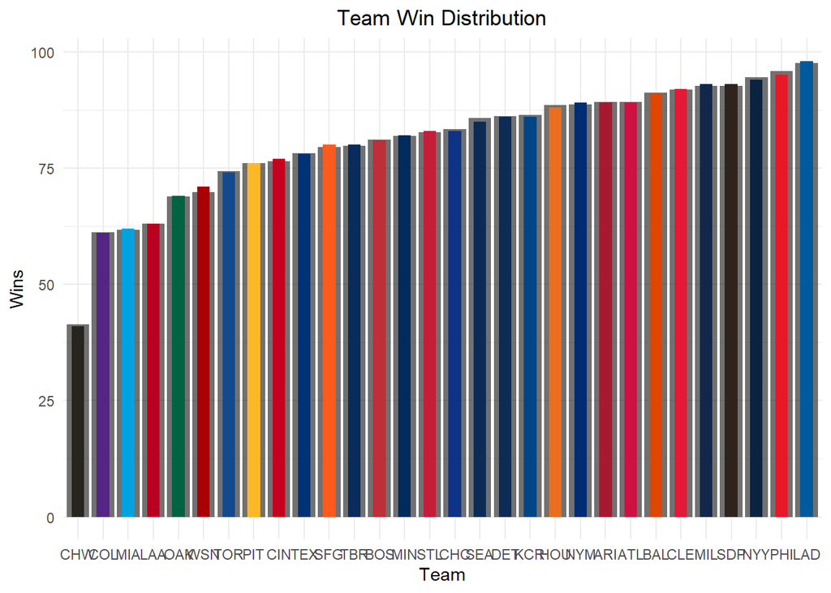

```r
ggplot(team_summary3, aes(x = reorder(team, Average_Wins))) +
  geom_col(aes(y = Average_Wins), fill = "gray7", alpha = 0.6) +
  geom_col(aes(y = total_wins, fill = team), width = 0.5) +
  scale_fill_manual(values = mlb_colors_custom) +
  labs(x = "Team", y = "Wins") +
  ggtitle("Team Win Distribution") +
  theme_minimal() +
  theme(legend.position = "none", plot.title = element_text(hjust = 0.5))
```

As with previous models, it appears that the theoretical win probabilities align very closely with the observed results, suggesting that these models suffer from over fitting based on the training data, and then failing to derive as accurate predictions on unseen data

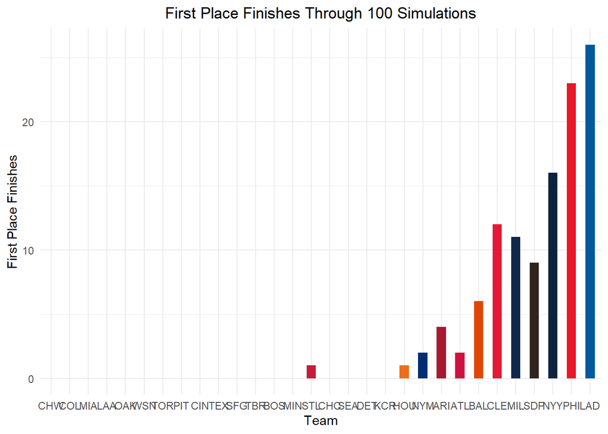

```r
ggplot(team_summary3, aes(x = reorder(team, Average_Wins))) +
  geom_col(aes(y = Times_1st, fill = team), width = 0.5) +
  scale_fill_manual(values = mlb_colors_custom) +
  labs(x = "Team", y = "First Place Finishes") +
  ggtitle("First Place Finishes Through 100 Simulations") +
  theme_minimal() +
  theme(legend.position = "none", plot.title = element_text(hjust = 0.5))
```

### Limitations and Future Considerations

Over fitting is an issue that appears to be inherent in the analysis, as the team strengths are being estimated based on one season and then, that season is re-simulated based off those estimated strengths. Naturally, when simulating that season a large amount of times, the distribution of the wins per team converges to the observed results. How much information do we truly gain through re simulating the same thing we’ve trained our model on? Additionally, team strengths are estimated off of starting pitcher performances that occurred during that season. This has the effect of simulating earlier games in the season which are partially based off games that happened in the future, which doesn’t really make much sense. There is a potential solution for this problem which is touched on in the next limitation.

Another considerable limitation of the model which considered starting pitchers was an inability to implement a feature which computed a delayed rolling average for ERA for each team. The intuition behind this feature is that for the first x, let’s say 10 games, a team’s average ERA is not representative of the long run average over the 162 game season. To combat this, a delayed rolling average is employed which only starts calculating after the 10th game. Before this mark, the ERA’s for each team are fixed at some reasonable, arbitrary constant; a value representative of an average league ERA.

Attempts to implement this feature proved to be quite difficult, and it was ultimately decided to exclude this feature from the model. An apparent side effect of not implementing this feature was a high amount of variance among certain individual game probabilities for the third model. Several games early in the season showed theoretical win probabilities close to 100% or 0%, a value almost certain to be false, as the value suggests that in 100,000 repeated attempts of the game, the opposing team would only win once. Thus, the model has less application to predicting the outcome of individual games as a result of this variance.

Another considerable limitation is the variation among how long a starting pitcher plays for, as well as potential correlation between number of innings pitched and ERA. Generally, starting pitchers pitch less innings when they are giving up too many runs, and pitch longer when they are giving up fewer runs. This variability in innings also affects the portion of the game pitched However, there is potential that this implication is less important than it seems in the sense that “bad” starting pitchers tend to pitch for shorter times after allowing multiple runs, while “good” starting pitchers tend to play for longer, as they are less likely to allow runs.

ERA is also not the end all be all statistic for measuring pitcher performance. ERA was used due to its simple format and recognizability, yet there are several other statistics that could be used in adjunct with ERA such as WHIP (Walks plus hits per Inning Pitched), ERA+ which standardizes ERA relative to the performance of other players in the league, and FIP (fielding independent pitching). Perhaps a linear combination of these metrics to quantify pitcher performance would remedy some of the high variance observed in the pitcher adjusted models.

Finally, running only 100 simulations for both evaluating model performance and simulating seasons leads to significant variability in results as opposed to running lets say 100,000 simulations. 100 was chosen due to the fact that it would not cause significant memory and timing issues on the local machine.

### Conclusions and Future Considerations

When considering future adjustments and improvements for these models, to truly capture the effect that pitching has on the outcome of a game, the other pitchers in the game must be accounted for. Due to the variability of the innings pitched per starting pitcher, the impact that relief pitchers have also varies, yet the total impact pitching has on the game is always the same if both groups are included.

Experimentation with the recent team form metric will also be considered, as although the initial results showed form as insignificant, perhaps this will change when altering the duration of games in which team form is considered. It may also be the case that starting pitcher performance is less dependent on team form of the other players, as starting pitchers don’t play nearly as often as everyone else.

Ultimately, it seems that not only has the Dodgers recent dominance not been due to mere chance, but more likely than not that the Dodgers are the dominant force in the league, especially when considering their star-studded lineup of pitchers. Perhaps the shocking results from our simulations express the need for adjustments to the structure of the league, as debates about a potential salary cap and lack of parity roar. Regardless, the results are clear; the Dodgers pitching staff has allowed them to find renewed success in recent times, and as highlighted by our models, their domination could continue even further given the frequency of finishes with the most wins in our simulations.